https://rponty.github.io/

# Analyzing the Relationship of Political Party in Power on United States Economics

> **by:** Carlos Berreteaga and Robinne Ponty

## 1. Introduction

- **Background**: This project stems from our curiosity about the claims made by different political parties regarding their policies and their effects on economy. Both parties often assert that their governance leads to better economic outcomes, but it can be challenging to discern which statements are credible. By exploring historical economic data in relation to political leadership, we aim to uncover patterns that clarify whether there's a tangible link between the political party in power and how well the economy is doing by several different meterics. Additionally, we want to identify how major economic indicators are influenced by different administrations. Furthermore, we also wish to see if we can predict how these indicators will fare in future administrations.
- **Research Question(s)**:
1. Do economic and political factors (e.g. GDP, CPI Food, Median Home Prices) significantly predict whether the president will be Republican or Democrat?
2. How is economy affected by the current political party in power? What factors are positively or negatively affected?
- **Objectives**:
  - To analyze realtionships between different parties and economic performance in order to:
    1. Predict future election results based on economic indicators
    2. Predict future values of economic indicators based on election results

## 2. Data Collection

### 2.1 Installing and Importing of Libraries and API

To begin, we are going have to import the necessary libraries that are needed for this project. In addition to this, we will also install an [API](https://www.ibm.com/topics/api) that we will need to obtain the financial data.

We will start by importing the necessary libraries, including [requests](https://pypi.org/project/requests/) for scraping political data off of particular websites, [Beautiful Soup](https://beautiful-soup-4.readthedocs.io/en/latest/) to read in the data, [pandas](https://pandas.pydata.org/docs/user_guide/index.html) and [numpy](https://numpy.org/) to help tidy the data, and [matplotlib](https://matplotlib.org/stable/api/pyplot_summary.html) to help visulaize it.

```python
import requests
from bs4 import BeautifulSoup
import pandas as pd
import numpy as np
import matplotlib.pyplot as plt
```

One of the key libraries that we are installing is [yfinance](https://pypi.org/project/yfinance/) for the Yahoo Finance data. We will be using this library in order to obtain the stock market data for the [S&P 500 index](https://www.investopedia.com/terms/s/sp500.asp).

```python
!pip install yfinance
import yfinance as yf
```

A large chunck of our data will be coming from [FRED API](https://fred.stlouisfed.org/docs/api/fred/) (Federal Reserve Economic Data) from the Federal Reserve Bank of St. Louis. From here, we will be extracting all sorts of national economic meterics including the Gross Domestic Product (GDP) and inflation data.

```python
!pip install fredapi
import fredapi as fa
```

### 2.2 Presidential Political Party Data

Our data collection begins by scraping data on U.S. presidents from Britannica to create a structured dataset that we can analyze later in connection with economics and political power. This information is important for understanding how different political leaders affect economic outcomes, helping us explore trends in policy impacts based on party affiliation. Ultimately, this organized dataset allows for a thorough analysis of the relationship between political power and economic conditions in the U.S., enhancing our understanding of how leadership and party ideology influence economic performance over time.

```python
 url = 'https://www.britannica.com/topic/Presidents-of-the-United-States-1846696'
response = requests.get(url)
soup = BeautifulSoup(response.content, 'html.parser')

# Initialize lists to store the scraped data
no = [] #numerical order president 1-46
presidents = []
birthplaces = []
parties = []
terms = []

table_rows = soup.find_all('tr')

for row in table_rows:
    columns = row.find_all('td')
    if len(columns) >= 5:  # Ensure that there are enough columns
        no.append(columns[1].text.strip())
        presidents.append(columns[2].text.strip())
        birthplaces.append(columns[3].text.strip())
        parties.append(columns[4].text.strip())
        terms.append(columns[5].text.strip())

# Create a DataFrame from the scraped data
presidents_df = pd.DataFrame({
    'No.': no,
    'President': presidents,
    'Birthplace': birthplaces,
    'President Party': parties,
    'Term': terms
})

display(presidents_df.head())
```

|  | No. | President | Birthplace | President Party | Term |
| --- | --- | --- | --- | --- | --- |
| 0 | 1 | George Washington | Virginia | Federalist | 1789–97 |
| 1 | 2 | John Adams | Massachusetts | Federalist | 1797–1801 |
| 2 | 3 | Thomas Jefferson | Virginia | Democratic-Republican | 1801–09 |
| 3 | 4 | James Madison | Virginia | Democratic-Republican | 1809–17 |
| 4 | 5 | James Monroe | Virginia | Democratic-Republican | 1817–25 |

We will also be adding the presidents state of residence to this current dataset from Wikipedia. This is done as in some cases (i.e. Barack Obama), the President's State of Birth happens to be different than their State of Residence. In the future, as we are analyzing how different industries are affected by the party in power, we thought that this might be interesting to see how their origin might have an impact. This is the third table on the website, so we need to take that into consideration.

```python
#Adding in the home state of each president
#Scraping from wikipedia
url = 'https://en.wikipedia.org/wiki/List_of_presidents_of_the_United_States_by_home_state'
response = requests.get(url)
soup = BeautifulSoup(response.content, 'html.parser')
#Setting up the columns of our database
president = []
home_state = []

#Now we find all the tables in the pages
lines = soup.find_all('table')
#As the table we want is the third one on the page, we need to index it as such so we can extract that information.
residency_table = lines[2]
#Now, extracting the information that is HTML marked td
residency_info = residency_table.find_all('td')
#Now just focusing on the elements of residency_info
num = 0
for ele in residency_info:
  #text stripping each element
  col = ele.text.strip()
  if num==0 or num ==3:
    num=0
  elif num == 1:
    president.append(col)
  elif num==2:
    #Wikipedia uses indexing to link pages together. This should remove the notes and indexes made
    while col[-1] in (']'):
        col = col[:-3]
    home_state.append(col)
  num+=1

#Some of the names that are included in this data set are slightly different, so we are changing them in accordance to the previous for the future
for i in range(len(president)):
  if president[i] == 'Richard Nixon':
      president[i]='Richard M. Nixon'
  elif president[i]=='Gerald Ford':
    president[i] = 'Gerald R. Ford'
  elif president [i] == 'George H. W. Bush':
    president[i] = 'George Bush'

#Finally, we need to make a dataframe for all this data.
home_state_df = pd.DataFrame({
    'President': president,
    'Residency': home_state
})


home_state_df.set_index('President',inplace=True)
display(home_state_df.head())
```

| President | Residency |
| --- | --- |
| George Washington | Virginia |
| John Adams | Massachusetts |
| Thomas Jefferson | Virginia |
| James Madison | Virginia |
| James Monroe | Virginia |

We now have two DataFrames that describe similar data. A smart thing to do going forward would be to put them together using the [pandas merge](https://pandas.pydata.org/pandas-docs/stable/reference/api/pandas.merge.html) function.

```python
# Merge the two dataframes
presidents_merged_df = pd.merge(presidents_df, home_state_df, on='President', how='left')
display(presidents_merged_df.head())
```

|  | No. | President | Birthplace | President Party | Term | Residency |
| --- | --- | --- | --- | --- | --- | --- |
| 0 | 1 | George Washington | Virginia | Federalist | 1789–97 | Virginia |
| 1 | 2 | John Adams | Massachusetts | Federalist | 1797–1801 | Massachusetts |
| 2 | 3 | Thomas Jefferson | Virginia | Democratic-Republican | 1801–09 | Virginia |
| 3 | 4 | James Madison | Virginia | Democratic-Republican | 1809–17 | Virginia |
| 4 | 5 | James Monroe | Virginia | Democratic-Republican | 1817–25 | Virginia |

### 2.3 Stock Market Data

We utilize the yfinance module and import it to download historical data for the S&P 500 index using its ticker symbol, "[^GSPC](https://finance.yahoo.com/quote/%5EGSPC/)" from Yahoo Finance, starting from January 1, 1927. We then resample this data to a yearly frequency by taking the last closing price for each year. This approach helps us create a structured dataset that captures the annual performance of the S&P 500, which is crucial for analyzing long-term market trends and understanding how economic conditions impact stock market performance over time.

```python
#Grab S&P 500 data from yfinance
ticker = "^GSPC"  #SP500 ticker
sp500_data = yf.download(ticker, start="1927-01-01")

# Resample the data to yearly frequency, taking the last closing price of each year
annual_data = sp500_data['Close'].resample('Y').last()

display(annual_data.head())
```

```
[*********************100%***********************]  1 of 1 completed
```

| Ticker Date | ^GSPC |
| --- | --- |
| 1927-12-31 | 17.660000 |
| 1928-12-31 | 24.350000 |
| 1929-12-31 | 21.450001 |
| 1930-12-31 | 15.340000 |
| 1931-12-31 | 8.120000 |

### 2.4 Additional Economic Data Points

As we contunue with this project, we might be interested in exploring the following points as a part of our analysis.

- **Economic Indicators**:
  - GDP Growth Rate
  - Unemployment Rate
  - Inflation Percentage
- **Market Sentiment Indicators**:
  - Consumer Confidence Index
  - Business Confidence Index
- **Monetary Policy Indicators**:
  - Interest Rates
- **Sector Performance**:
  - Sector-specific returns during different administrations.

To begine, we will be pulling the GDP (Gross Domestic Product, or the monetary measure of the market value of all the final goods and services produced and rendered) for the US using the [FRED API](https://fred.stlouisfed.org/docs/api/fred/). We need the API key in order access this.

To obtain an API Key:

1. Log onto https://fredaccount.stlouisfed.org/apikeys
2. Create an account
3. Log into you account using your account login
4. Click on "MyAccount"
5. Click on "API Keys"
6. Copy and paste the API key

We have already obtained an API key, and will be entering it into the fa.Fred function, as you can see below.

```python
fred = fa.Fred('1e0101660e1ddab96b83e504dde9cc31')
```

Getting the GDP by date from [FRED API](https://fred.stlouisfed.org/series/GDP/)

```python
gdp = fred.get_series('GDP')
gdp_df = pd.DataFrame(gdp).reset_index()
gdp_df.columns = ['Date', 'GDP']
display(gdp_df.head())
```

|  | Date | GDP |
| --- | --- | --- |
| 0 | 1946-01-01 | NaN |
| 1 | 1946-04-01 | NaN |
| 2 | 1946-07-01 | NaN |
| 3 | 1946-10-01 | NaN |
| 4 | 1947-01-01 | 243.164 |

Getting the Inflation Percentage by date from [FRED API](https://fred.stlouisfed.org/series/FPCPITOTLZGUSA). One thing to note here is that this number only state in increase of inflation per year as a percentage. This percentage does **compound** over time, but this incease will not will be reflected in our data. For example, in 1961, the inflation percentage was 1.07%, meaning that inflation and the general increase of average prices was about a cent per dollar. However, this does not account for the 1.46% inflation from the previous year (1960).

```python
inflation = fred.get_series('FPCPITOTLZGUSA')
#We will be creating a new DataFrame for all these values, then merging them later
inflation_df = pd.DataFrame(inflation).reset_index()
#Stating the columns of the 'Date' and the 'Inflation Percent'
inflation_df.columns = ['Date', 'Inflation']
inflation_df.head()
```

|  | Date | Inflation |
| --- | --- | --- |
| 0 | 1960-01-01 | 1.457976 |
| 1 | 1961-01-01 | 1.070724 |
| 2 | 1962-01-01 | 1.198773 |
| 3 | 1963-01-01 | 1.239669 |
| 4 | 1964-01-01 | 1.278912 |

Getting the Medain Cosumer Price Index (CPI) by date from [FRED API](https://fred.stlouisfed.org/series/MEDCPIM158SFRBCLE). This is the medain of the measure of average change over time in the prices paid by urban consumers for consumer goods and services. CPI can be considered a measure of inflation.

```python
median_cpi = fred.get_series('MEDCPIM158SFRBCLE')
median_cpi_df = pd.DataFrame(median_cpi).reset_index()
median_cpi_df.columns = ['Date', 'Median CPI']
median_cpi_df.head()
```

|  | Date | Median CPI |
| --- | --- | --- |
| 0 | 1983-01-01 | 5.014653 |
| 1 | 1983-02-01 | 4.952545 |
| 2 | 1983-03-01 | 3.612261 |
| 3 | 1983-04-01 | 4.828054 |
| 4 | 1983-05-01 | 3.767326 |

Getting the Median Home Prices by date from [FRED API](https://fred.stlouisfed.org/series/MSPUS).

```python
median_hp = fred.get_series('MSPUS')
median_hp_df = pd.DataFrame(median_hp).reset_index()
median_hp_df.columns = ['Date', 'Median Home Price']
median_hp_df.head()
```

|  | Date | Median Home Price |
| --- | --- | --- |
| 0 | 1963-01-01 | 17800.0 |
| 1 | 1963-04-01 | 18000.0 |
| 2 | 1963-07-01 | 17900.0 |
| 3 | 1963-10-01 | 18500.0 |
| 4 | 1964-01-01 | 18500.0 |

Getting the Comsumer Price Index for Food by date from [FRED API](https://fred.stlouisfed.org/series/CPIUFDSL), which is considered a measure of inflation in terms of food. We choose food for this one as this happens to be universal necessity for survival (not eveyone buys a house, but everyone does need to buy food).

```python
cpi_food = fred.get_series('CPIUFDSL')
cpi_food_df = pd.DataFrame(cpi_food).reset_index()
cpi_food_df.columns = ['Date', 'CPI Food']
cpi_food_df.head()
```

|  | Date | CPI Food |
| --- | --- | --- |
| 0 | 1947-01-01 | 22.8 |
| 1 | 1947-02-01 | 23.1 |
| 2 | 1947-03-01 | 23.8 |
| 3 | 1947-04-01 | 23.5 |
| 4 | 1947-05-01 | 23.4 |

Getting the Unemployment Rate by date from [FRED API](https://fred.stlouisfed.org/series/UNRATE). This is expressed as a percent of the unemployed people in the labor force.

```python
unemployment = fred.get_series('UNRATE')
unemployment_df = pd.DataFrame(unemployment).reset_index()
unemployment_df.columns = ['Date', 'Unemployment Rate']
unemployment_df.head()
```

|  | Date | Unemployment Rate |
| --- | --- | --- |
| 0 | 1948-01-01 | 3.4 |
| 1 | 1948-02-01 | 3.8 |
| 2 | 1948-03-01 | 4.0 |
| 3 | 1948-04-01 | 3.9 |
| 4 | 1948-05-01 | 3.5 |

Getting the Long Term Interest Rate by date from [FRED API](https://fred.stlouisfed.org/series/IRLTLT01USM156N). This influences how much a consumer's will have to pay to borrow or how much they happen to be paid to save for things that have a lifetime of greater than a year.

```python
ir_ltgby = fred.get_series('IRLTLT01USM156N')
ir_ltgby_df = pd.DataFrame(ir_ltgby).reset_index()
ir_ltgby_df.columns = ['Date', 'Long Term Interest Rate']
ir_ltgby_df.head()
```

|  | Date | Long Term Interest Rate |
| --- | --- | --- |
| 0 | 1953-04-01 | 2.83 |
| 1 | 1953-05-01 | 3.05 |
| 2 | 1953-06-01 | 3.11 |
| 3 | 1953-07-01 | 2.93 |
| 4 | 1953-08-01 | 2.95 |

Getting the Disposable Personal Income by date from [FRED API](https://fred.stlouisfed.org/series/FDEFX), or the amount that someone has to pay for things after taxes.

```python
nd_consumption = fred.get_series('FDEFX')
nd_consumption_df = pd.DataFrame(nd_consumption).reset_index()
nd_consumption_df.columns = ['Date', 'Disposable Personal Income']
nd_consumption_df.head()
```

|  | Date | Disposable Personal Income |
| --- | --- | --- |
| 0 | 1946-01-01 | NaN |
| 1 | 1946-04-01 | NaN |
| 2 | 1946-07-01 | NaN |
| 3 | 1946-10-01 | NaN |
| 4 | 1947-01-01 | 22.79 |

Getting the Consumer Confidence Index by date from [FRED API](https://fred.stlouisfed.org/series/CSCICP03USM665S). This measures how optimistic people are about the state of the economy. Note that this statistic is based on a monthly survey of 5,000 housholds.

```python
cci = fred.get_series('CSCICP03USM665S')
cci_df = pd.DataFrame(cci).reset_index()
cci_df.columns = ['Date', 'Consumer Confidence Index']
cci_df.head()
```

|  | Date | Consumer Confidence Index |
| --- | --- | --- |
| 0 | 1960-01-01 | 101.6328 |
| 1 | 1960-02-01 | 101.3749 |
| 2 | 1960-03-01 | 101.1521 |
| 3 | 1960-04-01 | 101.0292 |
| 4 | 1960-05-01 | 101.0603 |

### 2.5 Congress Political Party

For the final part of this tutorial, we will be taking in some data about the political makeup of the United States Congress. In particular, we will be seeing how the current party of Congress has an impact on the economy of the United States, how it may impact the results of the next election.

To begin, we will start by reading in the data from a .CSV file named 'senatecsv.csv' that we have attached to the file and read into a DataFrame by using the pandas [.readcsv](https://pandas.pydata.org/pandas-docs/stable/reference/api/pandas.read_csv.html) function to get the party majority for the Senate by year starting from 1983.

```python
senate_df = pd.read_csv('senatecsv.csv')

# Drop unnecessary columns
senate_df.drop(columns=['Unnamed: 0', 'Unnamed: 5', 'Unnamed: 6'], inplace=True)

# Rename columns
senate_df.rename(columns={
    'Unnamed: 1': 'Year',
    'Unnamed: 2': 'Senate Democrats',
    'Unnamed: 3': 'Senate Republicans',
    'Unnamed: 4': 'Senate Majority'
}, inplace=True)

senate_df.drop(index=0, inplace=True)
# Display the updated DataFrame
display(senate_df.head())
```

|  | Year | Senate Democrats | Senate Republicans | Senate Majority |
| --- | --- | --- | --- | --- |
| 1 | 1983 | 46 | 53 | Republican |
| 2 | 1984 | 45 | 55 | Republican |
| 3 | 1985 | 45 | 55 | Republican |
| 4 | 1986 | 47 | 53 | Republican |
| 5 | 1987 | 47 | 53 | Republican |

Now, we do the same thing, but for the House of Representatives thanks for the 'housecsv.csv'

```python
house_df = pd.read_csv('housecsv.csv')

# Drop unnecessary columns
house_df.drop(columns=['Unnamed: 0', 'Unnamed: 5', 'Unnamed: 6'], inplace=True)

# Rename columns
house_df.rename(columns={
    'Unnamed: 1': 'Year',
    'Unnamed: 2': 'House Democrats',
    'Unnamed: 3': 'House Republicans',
    'Unnamed: 4': 'House Majority'
}, inplace=True)

house_df.drop(index=0, inplace=True)
# Display the updated DataFrame
display(house_df.head())
```

|  | Year | House Democrats | House Republicans | House Majority |
| --- | --- | --- | --- | --- |
| 1 | 1983 | 269 | 165 | Democrat |
| 2 | 1984 | 269 | 165 | Democrat |
| 3 | 1985 | 253 | 181 | Democrat |
| 4 | 1986 | 253 | 181 | Democrat |
| 5 | 1987 | 258 | 177 | Democrat |

Once again, we use the merge function to merge both function on the year. We use the 'inner' option on the 'how' parameter in order to ensure that all the varaibles are used in this new DataFrame.

```python
senate_house_df = pd.merge(senate_df, house_df, on='Year', how='inner')
display(senate_house_df.head())
```

|  | Year | Senate Democrats | Senate Republicans | Senate Majority | House Democrats | House Republicans | House Majority |
| --- | --- | --- | --- | --- | --- | --- | --- |
| 0 | 1983 | 46 | 53 | Republican | 269 | 165 | Democrat |
| 1 | 1984 | 45 | 55 | Republican | 269 | 165 | Democrat |
| 2 | 1985 | 45 | 55 | Republican | 253 | 181 | Democrat |
| 3 | 1986 | 47 | 53 | Republican | 253 | 181 | Democrat |
| 4 | 1987 | 47 | 53 | Republican | 258 | 177 | Democrat |

Since all we are interested in is who has the majority in the Senate and the House, we can drop the columns with numbers using the [.drop](https://pandas.pydata.org/pandas-docs/stable/reference/api/pandas.DataFrame.drop.html) function from pandas in order to do away with the unnecessary numbers. At the end, we just have a DataFrame of the parties in control.

```python
senate_house_df.drop(columns=['Senate Democrats', 'Senate Republicans', 'House Democrats', 'House Republicans'], inplace=True)
senate_house_df.head()
```

|  | Year | Senate Majority | House Majority |
| --- | --- | --- | --- |
| 0 | 1983 | Republican | Democrat |
| 1 | 1984 | Republican | Democrat |
| 2 | 1985 | Republican | Democrat |
| 3 | 1986 | Republican | Democrat |
| 4 | 1987 | Republican | Democrat |

```python
 senate_house_df.dtypes
```

```
Year               object
Senate Majority    object
House Majority     object
dtype: object
```

## 3. Data Cleaning and Preparation

We begin Data Cleaning and Prepartion by processing the `Term` column in the `presidents_df` DataFrame by splitting it into `Start Year` and `End Year`. This allows us to better analyze each president's time in office.

We then define a function to convert the year values into a four-digit format, handling potential issues like missing values, special characters, and two-digit years. This ensures consistency and accuracy in our dataset. After applying this conversion function to both the `Start Year` and `End Year` columns, we update the `End Year` for each president to match the start year of the next president. For the last president, we manually set the `End Year` to 2024.

Finally, we drop the original `Term` column to streamline the dataset. This process enhances the dataset's usability for subsequent analyses of presidential terms in relation to economic and political dynamics.

```python
# Split the Term column into Start Year and End Year
presidents_merged_df[['Start Year', 'End Year']] = presidents_merged_df['Term'].str.split('–', expand=True)

# Function to convert to four-digit year format
def convert_year(year):
    if pd.isna(year) or year is None or year.strip() == '':
        return None
    year = year.strip()
    if year[-1] in ('*', '**'):
        year = year[:-1]  # Remove special characters
    try:
        year_int = int(year)
        # Handle two-digit years
        if year_int < 100:
            year_int += 2000 if year_int > 20 else 1900
        return f"{year_int:04d}"
    except ValueError:
        return None

# Apply the conversion function
presidents_merged_df['Start Year'] = presidents_merged_df['Start Year'].apply(convert_year)
presidents_merged_df['End Year'] = presidents_merged_df['End Year'].apply(convert_year)

# Shift the Start Year column to create the End Year based on the next president's start year
presidents_merged_df['End Year'] = presidents_merged_df['Start Year'].shift(-1)

# The last president's End Year should be 2024 it was showing NaN
presidents_merged_df.iloc[-1, presidents_merged_df.columns.get_loc('End Year')] = 2024
# Drop the original Term column
presidents_merged_df.drop(columns=['Term'], inplace=True)
```

The DataFrame Now looks like this.

```python
presidents_merged_df.head()
```

|  | No. | President | Birthplace | President Party | Residency | Start Year | End Year |
| --- | --- | --- | --- | --- | --- | --- | --- |
| 0 | 1 | George Washington | Virginia | Federalist | Virginia | 1789 | 1797 |
| 1 | 2 | John Adams | Massachusetts | Federalist | Massachusetts | 1797 | 1801 |
| 2 | 3 | Thomas Jefferson | Virginia | Democratic-Republican | Virginia | 1801 | 1809 |
| 3 | 4 | James Madison | Virginia | Democratic-Republican | Virginia | 1809 | 1817 |
| 4 | 5 | James Monroe | Virginia | Democratic-Republican | Virginia | 1817 | 1825 |

In this step, we calculate the yearly returns for the S&P 500 index by using the percentage change of the annual closing prices. We drop any missing values to ensure a clean dataset and create a new DataFrame, `yearly_returns_df`, that contains these returns with the appropriate column name.

Next, we reset the index of this DataFrame to include the year as a separate column for easier analysis. We also convert the year from a datetime format to a string format for better readability.

Additionally, we calculate the average closing price for the S&P 500 by resampling the data to a yearly frequency and taking the mean of the closing prices. This average closing price is stored in a new DataFrame, `avg_closing_price_df`, which also has the year included as a separate column after resetting the index. This process allows us to analyze the relationship between yearly returns and average closing prices, providing valuable insights into market performance over time.

```python
# Calculate yearly returns
yearly_returns = annual_data.pct_change().dropna()  # pct_change calculates the percentage change

yearly_returns_df = pd.DataFrame(yearly_returns)
yearly_returns_df.columns = ['Yearly Return']

# Reset the index to have the year as a column
yearly_returns_df.reset_index(inplace=True)

# Convert the year from datetime to a string for easier reading
yearly_returns_df['Year'] = yearly_returns_df['Date'].dt.year

# Calculate the average closing price
avg_closing_price = sp500_data['Close'].resample('Y').mean()

# Convert the average closing price to a DataFrame
avg_closing_price_df = pd.DataFrame(avg_closing_price)
avg_closing_price_df.columns = ['Avg Closing Price']

# Reset the index to have the year as a column
avg_closing_price_df.reset_index(inplace=True)
avg_closing_price_df['Year'] = avg_closing_price_df['Date'].dt.year
```

```python
avg_closing_price_df.head()
```

|  | Date | Avg Closing Price | Year |
| --- | --- | --- | --- |
| 0 | 1927-12-31 | 17.660000 | 1927 |
| 1 | 1928-12-31 | 19.937200 | 1928 |
| 2 | 1929-12-31 | 26.123936 | 1929 |
| 3 | 1930-12-31 | 21.033626 | 1930 |
| 4 | 1931-12-31 | 13.631071 | 1931 |

Next, we ensure that the `Start Year` and `End Year` columns in the `presidents_df` DataFrame are converted to integer format. This allows us to handle any non-numeric values more effectively by using `pd.to_numeric` with the `errors='coerce'` option, which replaces invalid entries with `NaN`. We then remove any rows that contain `NaN` values in these columns to maintain data integrity.

Following that, we create a new DataFrame that captures each year a president was in office. We iterate over each row of the cleaned `presidents_df`, extracting the start and end years for each president. For each year in that range, we create a new entry with the corresponding president's details (name, birthplace, and party).

After collecting this data, we convert the list of dictionaries into a DataFrame called `expanded_presidents_df`. Finally, we merge this new DataFrame with the `yearly_returns_df` on the `Year` column using a left join. This process enriches our dataset by linking presidential terms with yearly S&P 500 returns, facilitating further analysis of the economic impact of different presidencies.

```python
# Ensure the 'Start Year' and 'End Year' columns are integers
presidents_merged_df['Start Year'] = pd.to_numeric(presidents_merged_df['Start Year'], errors='coerce')
presidents_merged_df['End Year'] = pd.to_numeric(presidents_merged_df['End Year'], errors='coerce')

presidents_merged_df = presidents_merged_df.dropna(subset=['Start Year', 'End Year'])

# Create a DataFrame with each year a president was in office
expanded_presidents = []
for _, row in presidents_merged_df.iterrows():
    start_year = int(row['Start Year'])
    end_year = int(row['End Year'])
    for year in range(start_year, end_year + 1):
        expanded_presidents.append({
            'Year': year,
            'President': row['President'],
            'Party': row['President Party'],
            'Birthplace': row['Birthplace'],
            'Residency': row['Residency']
        })

# Convert the list to a DataFrame
expanded_presidents_df = pd.DataFrame(expanded_presidents)

# Merge the DataFrames on the 'Year' column
merged_df = pd.merge(expanded_presidents_df, yearly_returns_df, on='Year', how='left')
merged_df = merged_df.drop(columns = 'Date')
merged_df = merged_df.rename(columns = {'Yearly Return':'Yearly SP 500 Return (%)'})
merged_df['Yearly SP 500 Return (%)'] = merged_df['Yearly SP 500 Return (%)'] * 100
merged_df['Yearly SP 500 Return (%)'] = merged_df['Yearly SP 500 Return (%)'].round(decimals = 2)
```

It is here that we run into a slight problem. The S&P 500 as we know it did not start until 1928 with president Calvin Coolidge. Any earlier will result with NaNs in our data (which we do not want). Luckily, we can drop these and rewrite to our index using the following [Boolean Mask](https://www.programiz.com/python-programming/numpy/boolean-indexing) set for the year of 1928.

```python
merged_df = merged_df[merged_df['Year'] >= 1928]
 #This is the Boolean Mask, getting the data from the DataFrame by double brackets, indicating the column, and then using a comparative operator to get the piece of the DataFrame.
display(merged_df)
```

|  | Year | President | Party | Birthplace | Residency | Yearly SP 500 Return (%) |
| --- | --- | --- | --- | --- | --- | --- |
| 168 | 1928 | Calvin Coolidge | Republican | Vermont | Massachusetts | 37.88 |
| 169 | 1929 | Calvin Coolidge | Republican | Vermont | Massachusetts | -11.91 |
| 170 | 1929 | Herbert Hoover | Republican | Iowa | California | -11.91 |
| 171 | 1930 | Herbert Hoover | Republican | Iowa | California | -28.48 |
| 172 | 1931 | Herbert Hoover | Republican | Iowa | California | -47.07 |
| ... | ... | ... | ... | ... | ... | ... |
| 276 | 2021 | Donald Trump | Republican | New York | New York | 26.89 |
| 277 | 2021 | Joe Biden | Democratic | Pennsylvania | Delaware | 26.89 |
| 278 | 2022 | Joe Biden | Democratic | Pennsylvania | Delaware | -19.44 |
| 279 | 2023 | Joe Biden | Democratic | Pennsylvania | Delaware | 24.23 |
| 280 | 2024 | Joe Biden | Democratic | Pennsylvania | Delaware | 27.68 |

113 rows × 6 columns

In addition to the President and their political party, we will be including the Party that holds the Senate and the House of Representatives into the DataFrame. This is because wether or not we have a [divided government](https://en.wikipedia.org/wiki/Divided_government_in_the_United_States) can be a major factor in what legistiation is approved and which cabinet memebers are appointed, including those that may have an impact on the economy (such as the [Chair of the Federal Reserve](https://en.wikipedia.org/wiki/Divided_government_in_the_United_States)).

```python
#Due to the 'Year" column being a number that we will do Math with, we have to change our 'Year' column in our senate_house_df and merged_df into an int before merging.
senate_house_df['Year'] = senate_house_df['Year'].astype(int,errors='ignore')
merged_df['Year'] = merged_df['Year'].astype(int)

#Now we can merge the two factors using the 'inner' option on the how paramater.
merged_df = pd.merge(senate_house_df, merged_df, on='Year', how='inner')
merged_df.head()
```

|  | Year | Senate Majority | House Majority | President | Party | Birthplace | Residency | Yearly SP 500 Return (%) |
| --- | --- | --- | --- | --- | --- | --- | --- | --- |
| 0 | 1983 | Republican | Democrat | Ronald Reagan | Republican | Illinois | California | 17.27 |
| 1 | 1984 | Republican | Democrat | Ronald Reagan | Republican | Illinois | California | 1.40 |
| 2 | 1985 | Republican | Democrat | Ronald Reagan | Republican | Illinois | California | 26.33 |
| 3 | 1986 | Republican | Democrat | Ronald Reagan | Republican | Illinois | California | 14.62 |
| 4 | 1987 | Republican | Democrat | Ronald Reagan | Republican | Illinois | California | 2.03 |

Here we are striving to calculate the average yearly returns of the S&P 500 by political party using the `merged_df` DataFrame, which contains both presidential terms and yearly returns. We group the data by the `Party` column and compute the mean of the `Yearly Return` for each political party.

After calculating the averages, we reset the index to convert the grouped data back into a DataFrame format. We also rename the columns for clarity, changing them to `Party` and `Average Yearly Return`. This organized dataset allows us to easily compare the average yearly returns associated with different political parties, contributing to our analysis of the relationship between political leadership and economic performance.

```python
# Calculate average yearly returns by political party
average_returns = merged_df.groupby('Party')['Yearly SP 500 Return (%)'].mean().reset_index()

# Rename columns
average_returns.columns = ['Party', 'Average SP 500 Return (%)']
```

```python
average_returns.head()
```

|  | Party | Average SP 500 Return (%) |
| --- | --- | --- |
| 0 | Democratic | 13.279091 |
| 1 | Republican | 9.580769 |

Now, we have multiple datasets that we are able pull from. However, in order to be truly useful, we will nees to consolidate them all into one DataFrame. By using the [Pandas merge](https://pandas.pydata.org/pandas-docs/stable/reference/api/pandas.merge.html) function, we can create an ["Inner Join"](https://www.geeksforgeeks.org/different-types-of-joins-in-pandas/) on the Date that is able to put together all our economic data by date.

```python
dfs_to_merge = [
    gdp_df, inflation_df, median_cpi_df, median_hp_df, cpi_food_df,
    unemployment_df, ir_ltgby_df, nd_consumption_df, cci_df
]

# Start with the first dataframe
merged_fred_df = dfs_to_merge[0]

# Iterate through the remaining dataframes and merge them based on 'Date'
for df in dfs_to_merge[1:]:
  merged_fred_df = pd.merge(merged_fred_df, df, on='Date', how='inner')

merged_fred_df.tail()
```

|  | Date | GDP | Inflation | Median CPI | Median Home Price | CPI Food | Unemployment Rate | Long Term Interest Rate | Disposable Personal Income | Consumer Confidence Index |
| --- | --- | --- | --- | --- | --- | --- | --- | --- | --- | --- |
| 36 | 2019-01-01 | 21111.600 | 1.812210 | 2.889605 | 313000.0 | 256.533 | 4.0 | 2.71 | 838.831 | 101.00890 |
| 37 | 2020-01-01 | 21727.657 | 1.233584 | 3.739003 | 329000.0 | 261.262 | 3.6 | 1.76 | 871.343 | 101.59210 |
| 38 | 2021-01-01 | 22656.793 | 4.697859 | 1.171262 | 355000.0 | 271.226 | 6.4 | 1.08 | 905.020 | 99.22880 |
| 39 | 2022-01-01 | 25215.491 | 8.002800 | 6.735986 | 413500.0 | 290.217 | 4.0 | 1.76 | 903.677 | 97.72173 |
| 40 | 2023-01-01 | 27164.359 | 4.116338 | 7.406600 | 429000.0 | 319.623 | 3.4 | 3.53 | 976.929 | 97.35186 |

However, do note that the 'Date' index is set to a date, and will need it set to a year for future use. As of current, this is a [Timestamp object](https://pandas.pydata.org/pandas-docs/stable/reference/api/pandas.Timestamp.html). We will be extracting the year from this using the year attribute and the changing it into an interger using the [int function](https://www.geeksforgeeks.org/python-int-function/). This is because years a form of [interval data](https://helpfulprofessor.com/types-of-data/), meaning that we can use it for mathematical comparison in the future.

```python
col = merged_fred_df['Date']
years = []
for ind,row in merged_fred_df.iterrows():
  years.append(int(row['Date'].year))
```

Unfortunately, doing this mixed the data a bit. We now need to drop the 'Date' column and the reorganize the DataFrame so that it can be reorganized by Year. We will be doing this using double brackets.

```python
merged_fred_df['Year']=years
#We don't need the 'Date' column anymore, so we will drop it, being sure the inplace option is set to 'True' so it modifies the DataFrame
merged_fred_df.drop(columns='Date',inplace=True)
#Now to state how we want the columsn to be ordered as a list, and pass that into the DataFrame
merged_fred_df=merged_fred_df[['Year','GDP','Inflation','Median CPI','Median Home Price','CPI Food','Unemployment Rate','Long Term Interest Rate','Disposable Personal Income','Consumer Confidence Index']]
display(merged_fred_df.head())
```

|  | Year | GDP | Inflation | Median CPI | Median Home Price | CPI Food | Unemployment Rate | Long Term Interest Rate | Disposable Personal Income | Consumer Confidence Index |
| --- | --- | --- | --- | --- | --- | --- | --- | --- | --- | --- |
| 0 | 1983 | 3473.413 | 3.212435 | 5.014653 | 73300.0 | 98.1 | 10.4 | 10.46 | 261.538 | 98.42515 |
| 1 | 1984 | 3908.054 | 4.300535 | 4.852490 | 78200.0 | 102.0 | 8.0 | 11.67 | 287.855 | 101.37880 |
| 2 | 1985 | 4230.168 | 3.545644 | 3.074903 | 82800.0 | 104.7 | 7.3 | 11.38 | 313.912 | 101.01290 |
| 3 | 1986 | 4507.894 | 1.898048 | 4.423300 | 88000.0 | 107.5 | 6.7 | 9.19 | 339.119 | 101.05190 |
| 4 | 1987 | 4722.156 | 3.664563 | 5.358298 | 97900.0 | 111.8 | 6.6 | 7.08 | 361.483 | 100.49860 |

Now, we have to merge the politcal and economic DataFrames into one. Again, we will be using the merge function on 'Year' and be doing a left merge to orgainze the data based on the political dataset.

```python
merged_df = pd.merge(merged_df, merged_fred_df, on='Year', how='left')
display(merged_df.head())
```

|  | Year | Senate Majority | House Majority | President | Party | Birthplace | Residency | Yearly SP 500 Return (%) | GDP | Inflation | Median CPI | Median Home Price | CPI Food | Unemployment Rate | Long Term Interest Rate | Disposable Personal Income | Consumer Confidence Index |
| --- | --- | --- | --- | --- | --- | --- | --- | --- | --- | --- | --- | --- | --- | --- | --- | --- | --- |
| 0 | 1983 | Republican | Democrat | Ronald Reagan | Republican | Illinois | California | 17.27 | 3473.413 | 3.212435 | 5.014653 | 73300.0 | 98.1 | 10.4 | 10.46 | 261.538 | 98.42515 |
| 1 | 1984 | Republican | Democrat | Ronald Reagan | Republican | Illinois | California | 1.40 | 3908.054 | 4.300535 | 4.852490 | 78200.0 | 102.0 | 8.0 | 11.67 | 287.855 | 101.37880 |
| 2 | 1985 | Republican | Democrat | Ronald Reagan | Republican | Illinois | California | 26.33 | 4230.168 | 3.545644 | 3.074903 | 82800.0 | 104.7 | 7.3 | 11.38 | 313.912 | 101.01290 |
| 3 | 1986 | Republican | Democrat | Ronald Reagan | Republican | Illinois | California | 14.62 | 4507.894 | 1.898048 | 4.423300 | 88000.0 | 107.5 | 6.7 | 9.19 | 339.119 | 101.05190 |
| 4 | 1987 | Republican | Democrat | Ronald Reagan | Republican | Illinois | California | 2.03 | 4722.156 | 3.664563 | 5.358298 | 97900.0 | 111.8 | 6.6 | 7.08 | 361.483 | 100.49860 |

Something very particular happen though it we look at the tail of this DataFrame that we need to be aware of for future.

```python
merged_df.tail()
```

|  | Year | Senate Majority | House Majority | President | Party | Birthplace | Residency | Yearly SP 500 Return (%) | GDP | Inflation | Median CPI | Median Home Price | CPI Food | Unemployment Rate | Long Term Interest Rate | Disposable Personal Income | Consumer Confidence Index |
| --- | --- | --- | --- | --- | --- | --- | --- | --- | --- | --- | --- | --- | --- | --- | --- | --- | --- |
| 43 | 2021 | Republican | Democrat | Donald Trump | Republican | New York | New York | 26.89 | 22656.793 | 4.697859 | 1.171262 | 355000.0 | 271.226 | 6.4 | 1.08 | 905.020 | 99.22880 |
| 44 | 2021 | Republican | Democrat | Joe Biden | Democratic | Pennsylvania | Delaware | 26.89 | 22656.793 | 4.697859 | 1.171262 | 355000.0 | 271.226 | 6.4 | 1.08 | 905.020 | 99.22880 |
| 45 | 2022 | Republican | Democrat | Joe Biden | Democratic | Pennsylvania | Delaware | -19.44 | 25215.491 | 8.002800 | 6.735986 | 413500.0 | 290.217 | 4.0 | 1.76 | 903.677 | 97.72173 |
| 46 | 2023 | Republican | Republican | Joe Biden | Democratic | Pennsylvania | Delaware | 24.23 | 27164.359 | 4.116338 | 7.406600 | 429000.0 | 319.623 | 3.4 | 3.53 | 976.929 | 97.35186 |
| 47 | 2024 | Republican | Republican | Joe Biden | Democratic | Pennsylvania | Delaware | 27.68 | NaN | NaN | NaN | NaN | NaN | NaN | NaN | NaN | NaN |

As you can see, the last row for this intermediate DataFrame that we have made includes NaNs. This is because the data from the Federal Reserve is reported at the end of the year. Because 2024 has not ended at the time of this writing, this last row has nothing in it.

This affects us negatively, as we wanted to see the economic data for Joe Biden's last year of the presidency to help us predeict who would be the next president. Because of this, we will have to use 2023 as our last data point. Effectively, we will be substituting 2023 as 2024 only because these two years are not too far removed and the values not dramatically different. It also helps that the president is the same across both years.

It should be notes that even though the Stock Market reached its peak in 1928, most of the modern economic meterics that we use today did not appear until 1983. To account for this, we will be dropping the NaNs before this data so that our DataFrame does nto have large sections of missing data. We are choosing this because trying to fill this with the mean of the data or with another year would be inaccurate due to the large gap of time between 1928 and 1983. To do this, we will use the [.dropna](https://pandas.pydata.org/pandas-docs/stable/reference/api/pandas.DataFrame.dropna.html) function with 'inplace' once again set to 'True'.

```python
merged_df.dropna(inplace=True)
display(merged_df.head())
```

|  | Year | Senate Majority | House Majority | President | Party | Birthplace | Residency | Yearly SP 500 Return (%) | GDP | Inflation | Median CPI | Median Home Price | CPI Food | Unemployment Rate | Long Term Interest Rate | Disposable Personal Income | Consumer Confidence Index |
| --- | --- | --- | --- | --- | --- | --- | --- | --- | --- | --- | --- | --- | --- | --- | --- | --- | --- |
| 0 | 1983 | Republican | Democrat | Ronald Reagan | Republican | Illinois | California | 17.27 | 3473.413 | 3.212435 | 5.014653 | 73300.0 | 98.1 | 10.4 | 10.46 | 261.538 | 98.42515 |
| 1 | 1984 | Republican | Democrat | Ronald Reagan | Republican | Illinois | California | 1.40 | 3908.054 | 4.300535 | 4.852490 | 78200.0 | 102.0 | 8.0 | 11.67 | 287.855 | 101.37880 |
| 2 | 1985 | Republican | Democrat | Ronald Reagan | Republican | Illinois | California | 26.33 | 4230.168 | 3.545644 | 3.074903 | 82800.0 | 104.7 | 7.3 | 11.38 | 313.912 | 101.01290 |
| 3 | 1986 | Republican | Democrat | Ronald Reagan | Republican | Illinois | California | 14.62 | 4507.894 | 1.898048 | 4.423300 | 88000.0 | 107.5 | 6.7 | 9.19 | 339.119 | 101.05190 |
| 4 | 1987 | Republican | Democrat | Ronald Reagan | Republican | Illinois | California | 2.03 | 4722.156 | 3.664563 | 5.358298 | 97900.0 | 111.8 | 6.6 | 7.08 | 361.483 | 100.49860 |

Some of our observations (like Inflation) had more than one decimal place for their values. We will finish cleaning our economic data by using the [.round function](https://www.geeksforgeeks.org/round-function-python/) and rounding this data to two decimal places.

```python
#Making a list of columns that need to be rounded
cols = ['GDP','Inflation','Median CPI','CPI Food','Long Term Interest Rate','Disposable Personal Income','Consumer Confidence Index']
#Iterating over that list and applying the .round function to each column
for item in cols:
  merged_df[item] = merged_df[item].round(decimals = 2)

display(merged_df.head())
```

|  | Year | Senate Majority | House Majority | President | Party | Birthplace | Residency | Yearly SP 500 Return (%) | GDP | Inflation | Median CPI | Median Home Price | CPI Food | Unemployment Rate | Long Term Interest Rate | Disposable Personal Income | Consumer Confidence Index |
| --- | --- | --- | --- | --- | --- | --- | --- | --- | --- | --- | --- | --- | --- | --- | --- | --- | --- |
| 0 | 1983 | Republican | Democrat | Ronald Reagan | Republican | Illinois | California | 17.27 | 3473.41 | 3.21 | 5.01 | 73300.0 | 98.1 | 10.4 | 10.46 | 261.54 | 98.43 |
| 1 | 1984 | Republican | Democrat | Ronald Reagan | Republican | Illinois | California | 1.40 | 3908.05 | 4.30 | 4.85 | 78200.0 | 102.0 | 8.0 | 11.67 | 287.86 | 101.38 |
| 2 | 1985 | Republican | Democrat | Ronald Reagan | Republican | Illinois | California | 26.33 | 4230.17 | 3.55 | 3.07 | 82800.0 | 104.7 | 7.3 | 11.38 | 313.91 | 101.01 |
| 3 | 1986 | Republican | Democrat | Ronald Reagan | Republican | Illinois | California | 14.62 | 4507.89 | 1.90 | 4.42 | 88000.0 | 107.5 | 6.7 | 9.19 | 339.12 | 101.05 |
| 4 | 1987 | Republican | Democrat | Ronald Reagan | Republican | Illinois | California | 2.03 | 4722.16 | 3.66 | 5.36 | 97900.0 | 111.8 | 6.6 | 7.08 | 361.48 | 100.50 |

### Z-Scoring and Scaling for Percentage

For the next segement, we will be taking our DataFrame and the different economic factors to see if they happen to fall outside or a certain range. This is handy in the fact that in certain values like the Long Term Interest Rate, we don't really care about the number itself, but if the number is higher than average(indicating that economy is not doing great, and that more government control is needed) and how that impacts the economy. Read more about the Federal Reserve's goal for the Interest Rate here

Let's start by applying this to the Consumer Confidence Index.

```python
# Calculate the z-score for the 'Consumer Confidence Index'
merged_df['CCI Z-Score'] = (merged_df['Consumer Confidence Index'] - merged_df['Consumer Confidence Index'].mean()) / merged_df['Consumer Confidence Index'].std()
merged_df['CCI Z-Score'] = merged_df['CCI Z-Score'].round(decimals = 2)
# Display the DataFrame with the new z-score column
merged_df.head()
```

|  | Year | Senate Majority | House Majority | President | Party | Birthplace | Residency | Yearly SP 500 Return (%) | GDP | Inflation | Median CPI | Median Home Price | CPI Food | Unemployment Rate | Long Term Interest Rate | Disposable Personal Income | Consumer Confidence Index | CCI Z-Score |
| --- | --- | --- | --- | --- | --- | --- | --- | --- | --- | --- | --- | --- | --- | --- | --- | --- | --- | --- |
| 0 | 1983 | Republican | Democrat | Ronald Reagan | Republican | Illinois | California | 17.27 | 3473.41 | 3.21 | 5.01 | 73300.0 | 98.1 | 10.4 | 10.46 | 261.54 | 98.43 | -1.17 |
| 1 | 1984 | Republican | Democrat | Ronald Reagan | Republican | Illinois | California | 1.40 | 3908.05 | 4.30 | 4.85 | 78200.0 | 102.0 | 8.0 | 11.67 | 287.86 | 101.38 | 0.82 |
| 2 | 1985 | Republican | Democrat | Ronald Reagan | Republican | Illinois | California | 26.33 | 4230.17 | 3.55 | 3.07 | 82800.0 | 104.7 | 7.3 | 11.38 | 313.91 | 101.01 | 0.57 |
| 3 | 1986 | Republican | Democrat | Ronald Reagan | Republican | Illinois | California | 14.62 | 4507.89 | 1.90 | 4.42 | 88000.0 | 107.5 | 6.7 | 9.19 | 339.12 | 101.05 | 0.59 |
| 4 | 1987 | Republican | Democrat | Ronald Reagan | Republican | Illinois | California | 2.03 | 4722.16 | 3.66 | 5.36 | 97900.0 | 111.8 | 6.6 | 7.08 | 361.48 | 100.50 | 0.22 |

The other method of scaling is to find the percent of change that some of these factors have from year to year. We do this with the economic factors that have to do with how much people will pay. Since we don't want to erase the column, we will be making a new column in our DataFrame that will be named "______ Change %".

```python
#Putting all the columns in a list
columns_to_change = ['GDP', 'Median Home Price', 'CPI Food', 'Disposable Personal Income']
#Using a for loop to go through the list, find the percent change of everything in the list, and add it to the DataFrame
for col in columns_to_change:
    merged_df['{} Change (%)'.format(col)] = merged_df[col].pct_change() * 100  # Calculate percentage change and convert to percentage
    merged_df['{} Change (%)'.format(col)] = merged_df['{} Change (%)'.format(col)].round(2) #Rounding to two decimal places.
```

```python
#Cleaning Data
merged_df.drop_duplicates(subset='Year', keep='first', inplace=True)
merged_df = merged_df.reset_index(drop=True)
merged_df.head()
```

|  | Year | Senate Majority | House Majority | President | Party | Birthplace | Residency | Yearly SP 500 Return (%) | GDP | Inflation | ... | CPI Food | Unemployment Rate | Long Term Interest Rate | Disposable Personal Income | Consumer Confidence Index | CCI Z-Score | GDP Change (%) | Median Home Price Change (%) | CPI Food Change (%) | Disposable Personal Income Change (%) |
| --- | --- | --- | --- | --- | --- | --- | --- | --- | --- | --- | --- | --- | --- | --- | --- | --- | --- | --- | --- | --- | --- |
| 0 | 1983 | Republican | Democrat | Ronald Reagan | Republican | Illinois | California | 17.27 | 3473.41 | 3.21 | ... | 98.1 | 10.4 | 10.46 | 261.54 | 98.43 | -1.17 | NaN | NaN | NaN | NaN |
| 1 | 1984 | Republican | Democrat | Ronald Reagan | Republican | Illinois | California | 1.40 | 3908.05 | 4.30 | ... | 102.0 | 8.0 | 11.67 | 287.86 | 101.38 | 0.82 | 12.51 | 6.68 | 3.98 | 10.06 |
| 2 | 1985 | Republican | Democrat | Ronald Reagan | Republican | Illinois | California | 26.33 | 4230.17 | 3.55 | ... | 104.7 | 7.3 | 11.38 | 313.91 | 101.01 | 0.57 | 8.24 | 5.88 | 2.65 | 9.05 |
| 3 | 1986 | Republican | Democrat | Ronald Reagan | Republican | Illinois | California | 14.62 | 4507.89 | 1.90 | ... | 107.5 | 6.7 | 9.19 | 339.12 | 101.05 | 0.59 | 6.57 | 6.28 | 2.67 | 8.03 |
| 4 | 1987 | Republican | Democrat | Ronald Reagan | Republican | Illinois | California | 2.03 | 4722.16 | 3.66 | ... | 111.8 | 6.6 | 7.08 | 361.48 | 100.50 | 0.22 | 4.75 | 11.25 | 4.00 | 6.59 |

5 rows × 22 columns

The last thing that we will do here is [reorder the columns](https://www.geeksforgeeks.org/change-the-order-of-a-pandas-dataframe-columns-in-python/) of the DataFrame. This is simply to help us keep track of the the material we have in our DataFrame, especially since we have added columns that are scaled versions of other columns (ex. CPI Food Change %) for the visual anaylsis. It would be best to put these columns beside the column that they take their infromation from.

```python
# Desired column order
reorder_columns = [
    "Year", "President", "Party", "Birthplace", "Residency",
    "Senate Majority", "House Majority", "Yearly SP 500 Return (%)",
    "GDP", "GDP Change (%)", "Inflation", "Median CPI", "Median Home Price",
    "Median Home Price Change (%)", "CPI Food","CPI Food Change (%)", "Unemployment Rate",
    "Long Term Interest Rate", "Disposable Personal Income", "Disposable Personal Income Change (%)",
    "Consumer Confidence Index", "CCI Z-Score"
]

# Reorder the DataFrame columns
merged_df = merged_df[reorder_columns]
```

At the end, we have the following:

```python
display(merged_df)
```

|  | Year | President | Party | Birthplace | Residency | Senate Majority | House Majority | Yearly SP 500 Return (%) | GDP | GDP Change (%) | ... | Median Home Price | Median Home Price Change (%) | CPI Food | CPI Food Change (%) | Unemployment Rate | Long Term Interest Rate | Disposable Personal Income | Disposable Personal Income Change (%) | Consumer Confidence Index | CCI Z-Score |
| --- | --- | --- | --- | --- | --- | --- | --- | --- | --- | --- | --- | --- | --- | --- | --- | --- | --- | --- | --- | --- | --- |
| 0 | 1983 | Ronald Reagan | Republican | Illinois | California | Republican | Democrat | 17.27 | 3473.41 | NaN | ... | 73300.0 | NaN | 98.10 | NaN | 10.4 | 10.46 | 261.54 | NaN | 98.43 | -1.17 |
| 1 | 1984 | Ronald Reagan | Republican | Illinois | California | Republican | Democrat | 1.40 | 3908.05 | 12.51 | ... | 78200.0 | 6.68 | 102.00 | 3.98 | 8.0 | 11.67 | 287.86 | 10.06 | 101.38 | 0.82 |
| 2 | 1985 | Ronald Reagan | Republican | Illinois | California | Republican | Democrat | 26.33 | 4230.17 | 8.24 | ... | 82800.0 | 5.88 | 104.70 | 2.65 | 7.3 | 11.38 | 313.91 | 9.05 | 101.01 | 0.57 |
| 3 | 1986 | Ronald Reagan | Republican | Illinois | California | Republican | Democrat | 14.62 | 4507.89 | 6.57 | ... | 88000.0 | 6.28 | 107.50 | 2.67 | 6.7 | 9.19 | 339.12 | 8.03 | 101.05 | 0.59 |
| 4 | 1987 | Ronald Reagan | Republican | Illinois | California | Republican | Democrat | 2.03 | 4722.16 | 4.75 | ... | 97900.0 | 11.25 | 111.80 | 4.00 | 6.6 | 7.08 | 361.48 | 6.59 | 100.50 | 0.22 |
| 5 | 1988 | Ronald Reagan | Republican | Illinois | California | Democrat | Democrat | 12.40 | 5073.37 | 7.44 | ... | 110000.0 | 12.36 | 115.60 | 3.40 | 5.7 | 8.67 | 378.44 | 4.69 | 100.43 | 0.18 |
| 6 | 1989 | Ronald Reagan | Republican | Illinois | California | Democrat | Democrat | 27.25 | 5511.25 | 8.63 | ... | 118000.0 | 7.27 | 121.60 | 5.19 | 5.4 | 9.09 | 382.08 | 0.96 | 101.11 | 0.63 |
| 7 | 1990 | George Bush | Republican | Massachusetts | Texas | Democrat | Democrat | -6.56 | 5872.70 | 6.56 | ... | 123900.0 | 5.00 | 129.70 | 6.66 | 5.4 | 8.21 | 401.89 | 5.18 | 100.65 | 0.32 |
| 8 | 1991 | George Bush | Republican | Massachusetts | Texas | Democrat | Democrat | 26.31 | 6035.18 | 2.77 | ... | 120000.0 | -3.15 | 135.00 | 4.09 | 6.4 | 8.09 | 417.92 | 3.99 | 97.95 | -1.49 |
| 9 | 1992 | George Bush | Republican | Massachusetts | Texas | Democrat | Democrat | 4.46 | 6363.10 | 5.43 | ... | 119500.0 | -0.42 | 136.60 | 1.19 | 7.3 | 7.03 | 402.47 | -3.70 | 97.93 | -1.51 |
| 10 | 1993 | George Bush | Republican | Massachusetts | Texas | Democrat | Democrat | 7.06 | 6729.46 | 5.76 | ... | 125000.0 | 4.60 | 139.10 | 1.83 | 7.3 | 6.60 | 393.18 | -2.31 | 100.36 | 0.13 |
| 11 | 1994 | Bill Clinton | Democratic | Arkansas | Arkansas | Democrat | Democrat | -1.54 | 7115.65 | 5.74 | ... | 130000.0 | 4.00 | 142.90 | 2.73 | 6.6 | 5.75 | 376.42 | -4.26 | 100.68 | 0.35 |
| 12 | 1995 | Bill Clinton | Democratic | Arkansas | Arkansas | Democrat | Republican | 34.11 | 7522.29 | 5.71 | ... | 130000.0 | 0.00 | 146.70 | 2.66 | 5.6 | 7.78 | 380.10 | 0.98 | 101.14 | 0.65 |
| 13 | 1996 | Bill Clinton | Democratic | Arkansas | Arkansas | Republican | Republican | 20.26 | 7868.47 | 4.60 | ... | 137000.0 | 5.38 | 150.40 | 2.52 | 5.6 | 5.65 | 378.55 | -0.41 | 100.45 | 0.19 |
| 14 | 1997 | Bill Clinton | Democratic | Arkansas | Arkansas | Republican | Republican | 31.01 | 8362.66 | 6.28 | ... | 145000.0 | 5.84 | 155.90 | 3.66 | 5.3 | 6.58 | 362.79 | -4.16 | 101.45 | 0.86 |
| 15 | 1998 | Bill Clinton | Democratic | Arkansas | Arkansas | Republican | Republican | 26.67 | 8866.48 | 6.02 | ... | 152200.0 | 4.97 | 159.50 | 2.31 | 4.6 | 5.54 | 356.63 | -1.70 | 102.44 | 1.53 |
| 16 | 1999 | Bill Clinton | Democratic | Arkansas | Arkansas | Republican | Republican | 19.53 | 9411.68 | 6.15 | ... | 157400.0 | 3.42 | 163.00 | 2.19 | 4.3 | 4.72 | 372.23 | 4.37 | 102.14 | 1.33 |
| 17 | 2000 | Bill Clinton | Democratic | Arkansas | Arkansas | Republican | Republican | -10.14 | 10002.18 | 6.27 | ... | 165300.0 | 5.02 | 165.60 | 1.60 | 4.0 | 6.66 | 383.03 | 2.90 | 102.80 | 1.77 |
| 18 | 2001 | Bill Clinton | Democratic | Arkansas | Arkansas | Republican | Republican | -13.04 | 10470.23 | 4.68 | ... | 169800.0 | 2.72 | 170.30 | 2.84 | 4.2 | 5.16 | 404.46 | 5.59 | 101.10 | 0.63 |
| 19 | 2002 | George W. Bush | Republican | Connecticut | Texas | Democrat | Republican | -23.37 | 10783.50 | 2.99 | ... | 188700.0 | 11.13 | 175.30 | 2.94 | 5.7 | 5.04 | 440.90 | 9.01 | 100.60 | 0.29 |
| 20 | 2003 | George W. Bush | Republican | Connecticut | Texas | Democrat | Republican | 26.38 | 11174.13 | 3.62 | ... | 186000.0 | -1.43 | 177.10 | 1.03 | 5.8 | 4.05 | 494.98 | 12.27 | 99.57 | -0.40 |
| 21 | 2004 | George W. Bush | Republican | Connecticut | Texas | Republican | Republican | 8.99 | 11923.45 | 6.71 | ... | 212700.0 | 14.35 | 183.40 | 3.56 | 5.7 | 4.15 | 556.15 | 12.36 | 101.41 | 0.84 |
| 22 | 2005 | George W. Bush | Republican | Connecticut | Texas | Republican | Republican | 3.00 | 12767.29 | 7.08 | ... | 232500.0 | 9.31 | 188.70 | 2.89 | 5.3 | 4.22 | 598.42 | 7.60 | 101.08 | 0.61 |
| 23 | 2006 | George W. Bush | Republican | Connecticut | Texas | Republican | Republican | 13.62 | 13599.16 | 6.52 | ... | 247700.0 | 6.54 | 193.60 | 2.60 | 4.7 | 4.42 | 635.72 | 6.23 | 100.41 | 0.16 |
| 24 | 2007 | George W. Bush | Republican | Connecticut | Texas | Republican | Democrat | 3.53 | 14215.65 | 4.53 | ... | 257400.0 | 3.92 | 198.38 | 2.47 | 4.6 | 4.76 | 654.60 | 2.97 | 100.92 | 0.51 |
| 25 | 2008 | George W. Bush | Republican | Connecticut | Texas | Democrat | Democrat | -38.49 | 14706.54 | 3.45 | ... | 233900.0 | -9.13 | 208.13 | 4.91 | 5.0 | 3.74 | 721.21 | 10.18 | 98.74 | -0.96 |
| 26 | 2009 | George W. Bush | Republican | Connecticut | Texas | Democrat | Democrat | 23.45 | 14430.90 | -1.87 | ... | 208400.0 | -10.90 | 219.23 | 5.33 | 7.8 | 2.52 | 765.43 | 6.13 | 96.79 | -2.27 |
| 27 | 2010 | Barack Obama | Democratic | Hawaii | Illinois | Democrat | Democrat | 12.78 | 14764.61 | 2.31 | ... | 222900.0 | 6.96 | 218.49 | -0.34 | 9.8 | 3.73 | 817.51 | 6.80 | 98.51 | -1.12 |
| 28 | 2011 | Barack Obama | Democratic | Hawaii | Illinois | Democrat | Republican | -0.00 | 15351.45 | 3.97 | ... | 226900.0 | 1.79 | 222.47 | 1.82 | 9.1 | 3.39 | 831.59 | 1.72 | 98.65 | -1.02 |
| 29 | 2012 | Barack Obama | Democratic | Hawaii | Illinois | Democrat | Republican | 13.41 | 16068.80 | 4.67 | ... | 238400.0 | 5.07 | 232.21 | 4.38 | 8.3 | 1.97 | 824.08 | -0.90 | 98.52 | -1.11 |
| 30 | 2013 | Barack Obama | Democratic | Hawaii | Illinois | Democrat | Republican | 29.60 | 16648.19 | 3.61 | ... | 258400.0 | 8.39 | 236.01 | 1.64 | 8.0 | 1.91 | 774.68 | -5.99 | 98.77 | -0.94 |
| 31 | 2014 | Barack Obama | Democratic | Hawaii | Illinois | Democrat | Republican | 11.39 | 17197.74 | 3.30 | ... | 275200.0 | 6.50 | 238.49 | 1.05 | 6.6 | 2.86 | 744.99 | -3.83 | 99.41 | -0.51 |
| 32 | 2015 | Barack Obama | Democratic | Hawaii | Illinois | Republican | Republican | -0.73 | 18063.53 | 5.03 | ... | 289200.0 | 5.09 | 246.20 | 3.23 | 5.7 | 1.88 | 730.20 | -1.99 | 101.15 | 0.66 |
| 33 | 2016 | Barack Obama | Democratic | Hawaii | Illinois | Republican | Republican | 9.54 | 18525.93 | 2.56 | ... | 299800.0 | 3.67 | 248.35 | 0.87 | 4.8 | 2.09 | 726.55 | -0.50 | 100.71 | 0.37 |
| 34 | 2017 | Barack Obama | Democratic | Hawaii | Illinois | Republican | Republican | 19.42 | 19280.08 | 4.07 | ... | 313100.0 | 4.44 | 248.06 | -0.12 | 4.7 | 2.43 | 735.24 | 1.20 | 101.38 | 0.82 |
| 35 | 2018 | Donald Trump | Republican | New York | New York | Republican | Republican | -6.24 | 20328.55 | 5.44 | ... | 331800.0 | 5.97 | 252.38 | 1.74 | 4.0 | 2.58 | 773.14 | 5.15 | 101.37 | 0.81 |
| 36 | 2019 | Donald Trump | Republican | New York | New York | Republican | Democrat | 28.88 | 21111.60 | 3.85 | ... | 313000.0 | -5.67 | 256.53 | 1.64 | 4.0 | 2.71 | 838.83 | 8.50 | 101.01 | 0.57 |
| 37 | 2020 | Donald Trump | Republican | New York | New York | Republican | Democrat | 16.26 | 21727.66 | 2.92 | ... | 329000.0 | 5.11 | 261.26 | 1.84 | 3.6 | 1.76 | 871.34 | 3.88 | 101.59 | 0.96 |
| 38 | 2021 | Donald Trump | Republican | New York | New York | Republican | Democrat | 26.89 | 22656.79 | 4.28 | ... | 355000.0 | 7.90 | 271.23 | 3.82 | 6.4 | 1.08 | 905.02 | 3.87 | 99.23 | -0.63 |
| 39 | 2022 | Joe Biden | Democratic | Pennsylvania | Delaware | Republican | Democrat | -19.44 | 25215.49 | 11.29 | ... | 413500.0 | 16.48 | 290.22 | 7.00 | 4.0 | 1.76 | 903.68 | -0.15 | 97.72 | -1.65 |
| 40 | 2023 | Joe Biden | Democratic | Pennsylvania | Delaware | Republican | Republican | 24.23 | 27164.36 | 7.73 | ... | 429000.0 | 3.75 | 319.62 | 10.13 | 3.4 | 3.53 | 976.93 | 8.11 | 97.35 | -1.90 |

41 rows × 22 columns

## 4. Exploratory Data Analysis (EDA)

We start off our EDA by createing a visual representation of the S&P 500's yearly performance and average closing prices over time using Matplotlib.

First, we set up a figure with two subplots. The first subplot displays the yearly returns of the S&P 500. We plot the years on the x-axis and the corresponding yearly returns on the y-axis, using blue markers to highlight the data points. This graph helps us observe trends in the market's performance from year to year, providing insights into how economic conditions may fluctuate.

The second subplot focuses on the average closing price of the S&P 500 by year. Here, we use green markers to plot the average closing prices, which allows us to see how the overall market valuation changes over time.

Both plots are labeled appropriately, with titles, x and y labels, and grids for better readability. The [plt.tight_layout()](https://matplotlib.org/stable/api/_as_gen/matplotlib.pyplot.tight_layout.html) function ensures that the subplots do not overlap, making the graphs clearer and easier to interpret. Finally, we display the combined plots, offering a comprehensive view of the S&P 500's performance.

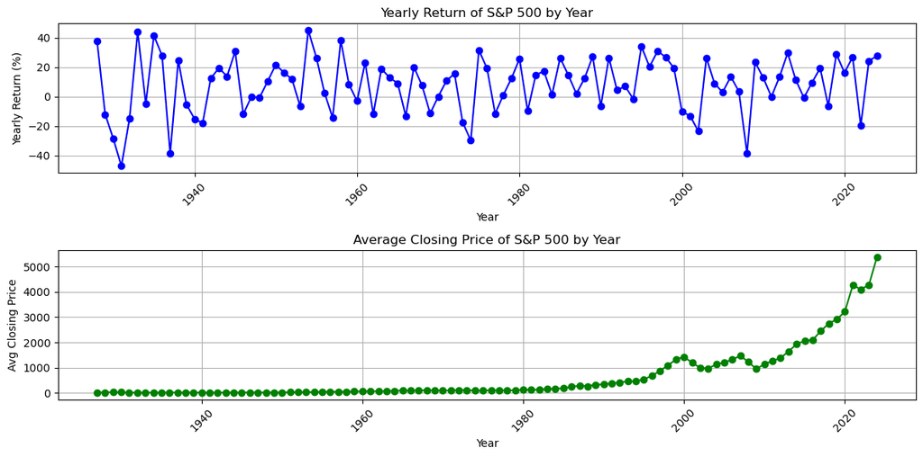

```python
#Plot the yearly returns
plt.figure(figsize=(12, 6))

plt.subplot(2, 1, 1)  # Create a subplot for yearly returns
plt.plot(yearly_returns_df['Year'], yearly_returns_df['Yearly Return']*100, marker='o', color='blue')
#Making titles and labels for the graph
plt.title('Yearly Return of S&P 500 by Year')
plt.xlabel('Year')
plt.ylabel('Yearly Return (%)')
plt.grid()
plt.xticks(rotation=45)

#Plot the average closing price per year
plt.subplot(2, 1, 2)  # Create a subplot for average closing price
plt.plot(avg_closing_price_df['Year'], avg_closing_price_df['Avg Closing Price'], marker='o', color='green')
#Making titles and labels for the graph
plt.title('Average Closing Price of S&P 500 by Year')
plt.xlabel('Year')
plt.ylabel('Avg Closing Price')
plt.grid()
plt.xticks(rotation=45)

# Adjust layout to prevent overlapping
plt.tight_layout()

plt.show()
```

### Economic Data and Presidential Terms by Political Party

We created a bar chart to visualize the the trends in economic meterics we introduced above againist the political party of the president in office during each year. First, a color mapping is defined for the two major political parties: red for the Republican Party and blue for the Democratic Party. This mapping helps differentiate the parties in the chart.

Appropriate titles and labels are added for both axes, along with a grid to enhance readability. A legend shows which color corresponds to each political party, providing context for the data.

Finally, the layout is adjusted to prevent overlapping elements, and the x-axis labels are rotated for better visibility. The resulting showing each economic factor from year-to-year and the what party was in power.

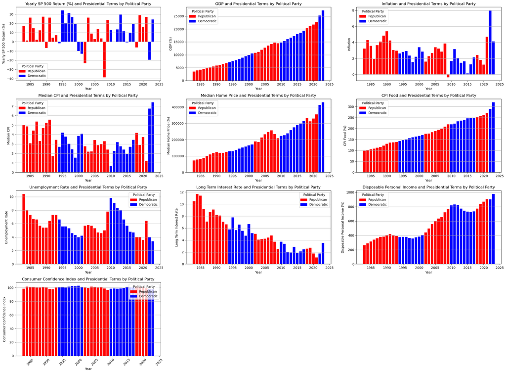

```python
# List of economic indicators to plot
economic_indicators = ['Yearly SP 500 Return (%)', 'GDP', 'Inflation', 'Median CPI',
                       'Median Home Price', 'CPI Food', 'Unemployment Rate',
                       'Long Term Interest Rate', 'Disposable Personal Income', 'Consumer Confidence Index']

# Color mapping for the political parties
party_colors = {'Republican': 'red', 'Democratic': 'blue'}

# Number of subplots needed
n_indicators = len(economic_indicators)
n_cols = 3  # Number of columns for subplots
n_rows = (n_indicators + n_cols - 1) // n_cols  # Calculate number of rows needed

# Create subplots
fig, axes = plt.subplots(n_rows, n_cols, figsize=(22, n_rows * 4))
axes = axes.flatten()  # Flatten the 2D array of axes for easy iteration

# Generate bar plots for each economic indicator
for idx, indicator in enumerate(economic_indicators):
    # Map political party colors to the bars
    bar_colors = merged_df['Party'].map(party_colors)

    # Create bar plot
    axes[idx].bar(merged_df['Year'], merged_df[indicator], color=bar_colors)

    # Titles and labels
    axes[idx].set_title(f'{indicator} and Presidential Terms by Political Party')
    axes[idx].set_xlabel('Year')
    axes[idx].set_ylabel(f'{indicator} (%)' if indicator in columns_to_change else indicator)
    axes[idx].grid(axis='y')

    # Legend
    handles = [plt.Rectangle((0, 0), 1, 1, color=party_colors[party]) for party in party_colors]
    axes[idx].legend(handles, party_colors.keys(), title='Political Party')

# Hide any unused subplots
for j in range(idx + 1, len(axes)):
    fig.delaxes(axes[j])

plt.tight_layout()
plt.xticks(rotation=45)
plt.show()
```

### Average Returns by Political Party

It's also a good quick way to check if the common beliefs about which political party is better for the economy actually match up with the data. It may not answer our entire question, but for investors, this kind of information could be useful when thinking about long-term strategies, especially during election years when leadership changes might affect the market.

Below is the chart that the data is based on.

```python
average_returns = merged_df[['Party','Yearly SP 500 Return (%)']]
average_returns.head()
```

|  | Party | Yearly SP 500 Return (%) |
| --- | --- | --- |
| 0 | Republican | 17.27 |
| 1 | Republican | 1.40 |
| 2 | Republican | 26.33 |
| 3 | Republican | 14.62 |
| 4 | Republican | 2.03 |

### Comparing the Average Economic Metrics by Political Party

Now that we have done the S&P 500 Average Comparison above, we can apply this logic to the other Economic Metrics to gain better insight on how politics influences the economy. Instead of graphing these things directly, we will graphing the percent change. (Though we should point out that certain factors from above such as Inflation, Median CPI, Unemployment Rate, and Long Term Interest Rate, are already reported in such a matter). Note that To save time, we will be making a list of these factors and using a for loop to make a graph of each. Also note that we will not be looking at the % chnage in CCI, but instead the CCI Z-Score, as explained above.

```python
merged_df.columns
```

```
Index(['Year', 'President', 'Party', 'Birthplace', 'Residency',
       'Senate Majority', 'House Majority', 'Yearly SP 500 Return (%)', 'GDP',
       'GDP Change (%)', 'Inflation', 'Median CPI', 'Median Home Price',
       'Median Home Price Change (%)', 'CPI Food', 'CPI Food Change (%)',
       'Unemployment Rate', 'Long Term Interest Rate',
       'Disposable Personal Income', 'Disposable Personal Income Change (%)',
       'Consumer Confidence Index', 'CCI Z-Score'],
      dtype='object')
```

[figure not shown]

```python
# List of economic indicators to plot
economic_indicators = ['Yearly SP 500 Return (%)', 'GDP Change (%)', 'Inflation', 'Median CPI',
                       'Median Home Price Change (%)', 'CPI Food Change (%)', 'Unemployment Rate',
                       'Long Term Interest Rate', 'Disposable Personal Income Change (%)',
                       'CCI Z-Score']

# Color mapping for the political parties
party_colors = {'Republican': 'red', 'Democratic': 'blue'}

# Number of subplots needed
n_indicators = len(economic_indicators)
n_cols = 2  # Number of columns for subplots
n_rows = (n_indicators + n_cols - 1) // n_cols  # Calculate number of rows needed

# Create subplots
fig, axes = plt.subplots(n_rows, n_cols, figsize=(22, n_rows * 5))
axes = axes.flatten()  # Flatten the 2D array of axes for easy iteration

# Generate bar plots for each economic indicator
for idx, indicator in enumerate(economic_indicators):
    # Map political party colors to the bars
    bar_colors = merged_df['Party'].map(party_colors)

    # Create bar plot
    axes[idx].bar(merged_df['Year'], merged_df[indicator], color=bar_colors)

    # Titles and labels
    axes[idx].set_title(f'{indicator} and Presidential Terms by Political Party')
    axes[idx].set_xlabel('Year')
    axes[idx].set_ylabel(f'{indicator} (%)' if indicator in columns_to_change else indicator)
    axes[idx].grid(axis='y')

    # Legend
    handles = [plt.Rectangle((0, 0), 1, 1, color=party_colors[party]) for party in party_colors]
    axes[idx].legend(handles, party_colors.keys(), title='Political Party')

# Hide any unused subplots
for j in range(idx + 1, len(axes)):
    fig.delaxes(axes[j])

plt.tight_layout()
plt.xticks(rotation=45)
plt.show()
```

This is better! We can now see the effect of parties across time and which party got us clearer high and low points!

But here is the thing. Our question is not "How is the economy affected by political parties across time?", it is "How is economy affected by the current political party in power?" Whether it is 1984 or 2024 makes no difference (the time dimension is excessive), we just want to find the party that is better for the economy overall.

Let's do this instead. How about we use the [pandas pd.groupby](https://pandas.pydata.org/pandas-docs/stable/reference/api/pandas.DataFrame.groupby.html) to group the DataFrame in both political Parties, and then graph them. We will use the [.mean()](https://www.geeksforgeeks.org/python-statistics-mean-function/) function to compile the values in order to create a fair comparision between the two parties.

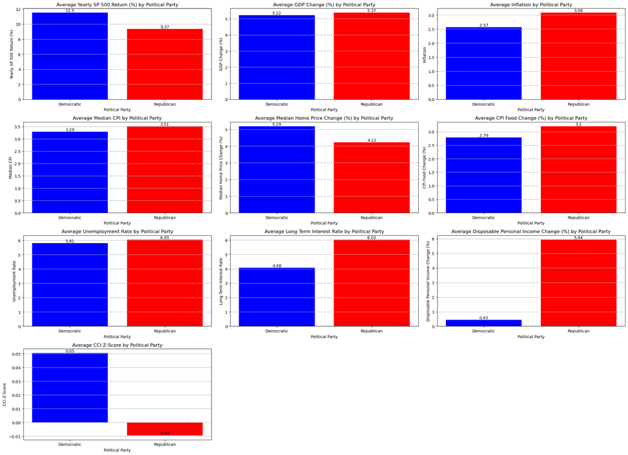

```python
# List of economic indicators
economic_indicators = ['Yearly SP 500 Return (%)', 'GDP Change (%)', 'Inflation', 'Median CPI',
                       'Median Home Price Change (%)', 'CPI Food Change (%)', 'Unemployment Rate',
                       'Long Term Interest Rate', 'Disposable Personal Income Change (%)', 'CCI Z-Score']

# Define colors for the parties
party_colors = {'Republican': 'red', 'Democratic': 'blue'}

# Number of subplots needed
n_indicators = len(economic_indicators)
n_cols = 3  # Number of columns for subplots
n_rows = (n_indicators + n_cols - 1) // n_cols  # Calculate number of rows needed

# Create subplots
fig, axes = plt.subplots(n_rows, n_cols, figsize=(22, n_rows * 4))
axes = axes.flatten()  # Flatten the 2D array of axes for easy iteration

# Loop through each economic indicator and create a bar plot
for idx, indicator in enumerate(economic_indicators):
    # Group by party and calculate the mean of the current indicator
    average_indicator = merged_df.groupby('Party')[indicator].mean().reset_index()

    # Create bar plot
    bars = axes[idx].bar(average_indicator['Party'], average_indicator[indicator],
                         color=[party_colors[party] for party in average_indicator['Party']])

    # Titles and labels
    axes[idx].set_title(f'Average {indicator} by Political Party')
    axes[idx].set_xlabel('Political Party')
    axes[idx].set_ylabel(indicator)
    axes[idx].grid(axis='y')

    # Add data labels on top of bars
    for bar in bars:
        yval = bar.get_height()
        axes[idx].text(bar.get_x() + bar.get_width()/2, yval, round(yval, 2), ha='center', va='bottom')

# Hide any unused subplots
for j in range(idx + 1, len(axes)):
    fig.delaxes(axes[j])

plt.tight_layout()
plt.show()
```

Disposable Income by Political Party was the first graph that surprised us. Despite most of the other graphs showing that the value of goods was cheaper under a democratic administration, this graph showed that Americains had more money in their pockets for spending under a republician administration. We will have to conduct further analysis on this, but this may tie into the other graph we want to analyze.

Finally, the last interesting graph was the unemployment rate average between parties. Despite both parties promising more jobs for more Americians, it seems that there is not a significant correlation between the two. It seems that, despite who is in power, the unemployment rate seems to stay steady. We will have to do further research as to why, but it is an interesting comparison to see nonetheless.

### Residency and Inflation Percentage

Below, we will be looking into something fun that we were considering: "Does the state that the President resides in have an impact on the economy?" As seen above, we obtained the Presdient's State of Residence (as this may be different than the state of birth). We now will be comparing this to the Inflation. We again will be using the [.mean()](https://www.geeksforgeeks.org/python-statistics-mean-function/) function to get the Average Percent of Inflation from year to year.

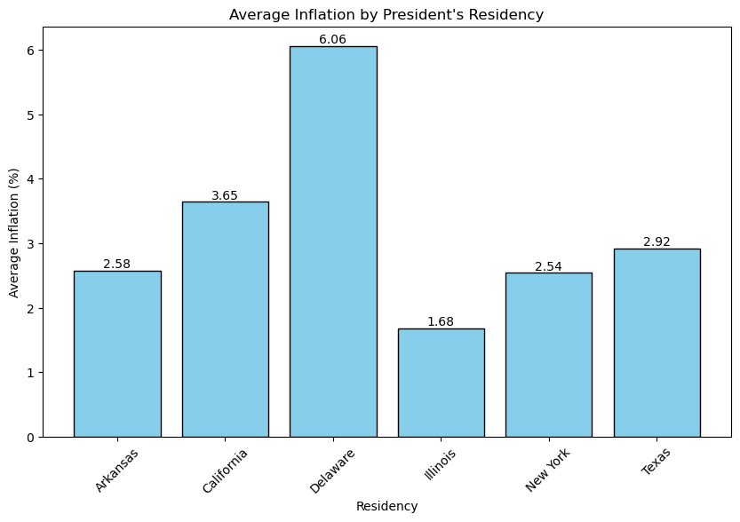

```python
residency_inflation = merged_df.groupby('Residency')['Inflation'].mean()

# Plot
plt.figure(figsize=(10, 6))
bars = plt.bar(residency_inflation.index, residency_inflation.values, color='skyblue', edgecolor='black')

# Adding title and labels
plt.title('Average Inflation by President\'s Residency')
plt.xlabel('Residency')
plt.ylabel('Average Inflation (%)')

# Display values on top of each bar
for bar in bars:
    yval = bar.get_height()
    plt.text(bar.get_x() + bar.get_width()/2, yval, round(yval, 2), ha='center', va='bottom')

plt.xticks(rotation=45)
plt.show()
```

Overall though, there is not anything really useful in here. We have too few residency states (6) to make this work. If we had more states and more data, perhaps we could make more out of this.

### Inflation Percentage Distribution

In this graph, we will be looking into the Inflation rate in order to see how far the range of the Inflation Rate extends.

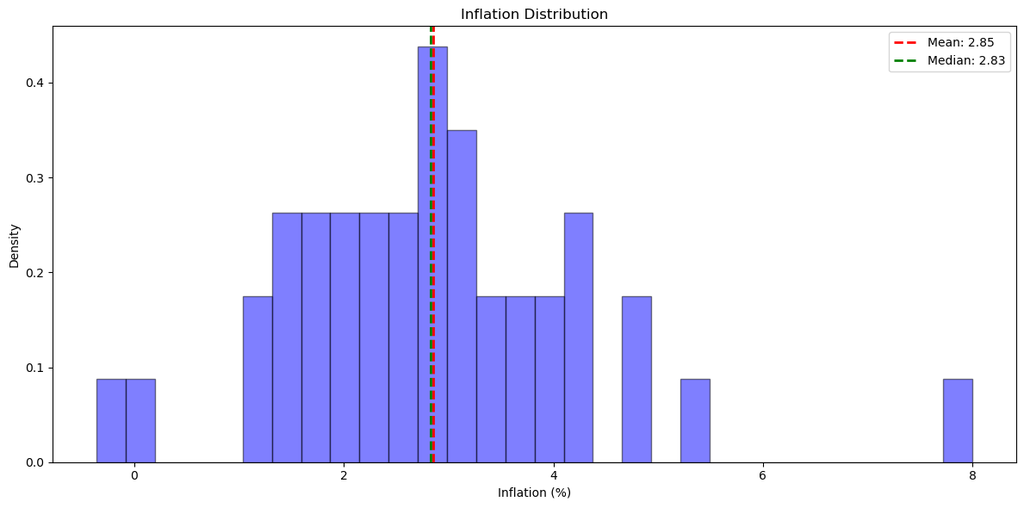

```python
inflation_data = merged_df['Inflation'].dropna()  # Remove any NaN values

# Calculate mean and median
mean_inflation = np.mean(inflation_data)
median_inflation = np.median(inflation_data)

# Create a histogram
plt.figure(figsize=(12, 6))
plt.hist(inflation_data, bins=30, alpha=0.5, color='blue', edgecolor='black', density=True)

# Plot mean and median lines
mean_line = plt.axvline(mean_inflation, color='red', linestyle='dashed', linewidth=2, label=f'Mean: {mean_inflation:.2f}')
median_line = plt.axvline(median_inflation, color='green', linestyle='dashed', linewidth=2, label=f'Median: {median_inflation:.2f}')

# Titles and labels
plt.title('Inflation Distribution')
plt.xlabel('Inflation (%)')
plt.ylabel('Density')
plt.legend()

plt.tight_layout()
plt.show()
```

From the graph, we have a very obvious outlier in terms of 8% (under Joe Biden's presidency). This was somewhat expected from our previous data. In addition to this, we see that this skews the data to the right, as the Mean is higher than the Median and the tail is right leaning. However, what was surprising to us was how much the lean is, and it only has the difference of 0.02. This is not statisically significant and shows that while 8% is shocking and seems to be affecting us a lot in the day to day, it may not be as dramatic for the economy overall as everyone thinks. While, it devalued the American dollar alot for one year, but it not offset inflation from the Federal Reserve's goal an average of 2% inflation. Read more about the Federal Reserve's goal for inflation [here](https://www.federalreserve.gov/faqs/economy_14400.htm).

## 5. Model Development

### Part I: Predictive Modeling of the Future President

Here, we will be attempting to see how economics factor in Americians choosing a future President. To do this will use our Data Frame of economic factors and put it through a [Random Forest](https://www.geeksforgeeks.org/random-forest-algorithm-in-machine-learning/) analysis, as we are making a classifiaction model. We choose this type of model as because it is well-suited for structured data like ours which includes both non-linear and complex interactions between features. Unlike simpler models, a Random Forest can capture nuanced patterns without requiring extensive preparation beforehand. It also provides interpretable feature importance scores, allowing us to understand which predictors, such as CPI Food, GDP, and Median Home Price, are most influential in determining the election outcome. Additionally, Random Forest is less likely to overfit due to it combining the results of many trees, making it work well even with a relatively small dataset. Overall, Random Forest is a good balance between accuracy and understanding, which makes it a solid choice for our project.

**Please Note**: We fully recognize the fact that this is not going to be a "crystal ball" to predict the outcomes of all future elections, and that other highly important factors (such as foriegn and domestic policy, past politcal expericence, age) go into how a president is elected. This model simply is looking at how the current state of the economy factors into voters' thinking in a presidential race.

### Z-Scoring###

```python
columns_to_zscore = ['Yearly SP 500 Return (%)', 'GDP','Median CPI', 'Median Home Price', 'CPI Food', 'Unemployment Rate', 'Long Term Interest Rate', 'Disposable Personal Income', 'Consumer Confidence Index']

columns_to = ['Year','President','Party', 'Birthplace', 'Residency', 'Senate Majority', 'House Majority']

z_score_df = pd.DataFrame()
for col in columns_to:
  z_score_df[col] = merged_df[col]


z_score_df[columns_to_zscore] = (merged_df[columns_to_zscore] - merged_df[columns_to_zscore].mean()) / merged_df[columns_to_zscore].std()

s_score_df = z_score_df.round(decimals = 2)
s_score_df.head()
```

|  | Year | President | Party | Birthplace | Residency | Senate Majority | House Majority | Yearly SP 500 Return (%) | GDP | Median CPI | Median Home Price | CPI Food | Unemployment Rate | Long Term Interest Rate | Disposable Personal Income | Consumer Confidence Index |
| --- | --- | --- | --- | --- | --- | --- | --- | --- | --- | --- | --- | --- | --- | --- | --- | --- |
| 0 | 1983 | Ronald Reagan | Republican | Illinois | California | Republican | Democrat | 0.43 | -1.38 | 1.14 | -1.41 | -1.52 | 2.64 | 1.87 | -1.42 | -1.20 |
| 1 | 1984 | Ronald Reagan | Republican | Illinois | California | Republican | Democrat | -0.55 | -1.31 | 1.02 | -1.35 | -1.46 | 1.22 | 2.30 | -1.30 | 0.81 |
| 2 | 1985 | Ronald Reagan | Republican | Illinois | California | Republican | Democrat | 0.98 | -1.26 | -0.24 | -1.30 | -1.41 | 0.80 | 2.20 | -1.18 | 0.56 |
| 3 | 1986 | Ronald Reagan | Republican | Illinois | California | Republican | Democrat | 0.26 | -1.22 | 0.72 | -1.25 | -1.36 | 0.45 | 1.42 | -1.06 | 0.58 |
| 4 | 1987 | Ronald Reagan | Republican | Illinois | California | Republican | Democrat | -0.51 | -1.19 | 1.38 | -1.14 | -1.29 | 0.39 | 0.68 | -0.96 | 0.21 |

Some of these entries unfortuately have categorical data. Fortunately, most it says whether or not the dominant party is either a Republican or Democrat. This means we can easily use the [.get_dummies](https://pandas.pydata.org/pandas-docs/stable/reference/api/pandas.get_dummies.html) function.

```python
z_score_df = pd.get_dummies(z_score_df, columns=['Party', 'Senate Majority','House Majority'])
z_score_df.head()
```

|  | Year | President | Birthplace | Residency | Yearly SP 500 Return (%) | GDP | Median CPI | Median Home Price | CPI Food | Unemployment Rate | Long Term Interest Rate | Disposable Personal Income | Consumer Confidence Index | Party_Democratic | Party_Republican | Senate Majority_Democrat | Senate Majority_Republican | House Majority_Democrat | House Majority_Republican |
| --- | --- | --- | --- | --- | --- | --- | --- | --- | --- | --- | --- | --- | --- | --- | --- | --- | --- | --- | --- |
| 0 | 1983 | Ronald Reagan | Illinois | California | 0.426490 | -1.380970 | 1.135828 | -1.405866 | -1.523926 | 2.644429 | 1.873531 | -1.422287 | -1.201975 | False | True | False | True | True | False |
| 1 | 1984 | Ronald Reagan | Illinois | California | -0.545368 | -1.312865 | 1.022107 | -1.353373 | -1.456599 | 1.220172 | 2.301912 | -1.300011 | 0.809911 | False | True | False | True | True | False |
| 2 | 1985 | Ronald Reagan | Illinois | California | 0.981313 | -1.262391 | -0.243045 | -1.304094 | -1.409987 | 0.804763 | 2.199242 | -1.178990 | 0.557573 | False | True | False | True | True | False |
| 3 | 1986 | Ronald Reagan | Illinois | California | 0.264208 | -1.218874 | 0.716480 | -1.248387 | -1.361650 | 0.448699 | 1.423908 | -1.061872 | 0.584853 | False | True | False | True | True | False |
| 4 | 1987 | Ronald Reagan | Illinois | California | -0.506787 | -1.185299 | 1.384594 | -1.142330 | -1.287417 | 0.389355 | 0.676896 | -0.957994 | 0.209755 | False | True | False | True | True | False |

In order to create effective models later, we need to replace these True/False statements with 1s and 0s. Meaning that they are numerical data that we can later use.

```python
# Encode True/False columns as 1/0
z_score_df['Party_Democratic'] = z_score_df['Party_Democratic'].astype(int)
z_score_df['Party_Republican'] = z_score_df['Party_Republican'].astype(int)
z_score_df['Senate Majority_Democrat'] = z_score_df['Senate Majority_Democrat'].astype(int)
z_score_df['Senate Majority_Republican'] = z_score_df['Senate Majority_Republican'].astype(int)
z_score_df['House Majority_Democrat'] = z_score_df['House Majority_Democrat'].astype(int)
z_score_df['House Majority_Republican'] = z_score_df['House Majority_Republican'].astype(int)

# You can also encode 'Birthplace' and 'Residency' into numerical values if needed
z_score_df['Birthplace'] = z_score_df['Birthplace'].astype('category').cat.codes
z_score_df['Residency'] = z_score_df['Residency'].astype('category').cat.codes

# Optionally, drop columns you don't want to include in the model
z_score_df = z_score_df.drop(columns=['President'])
```

Our new DataFrame looks like this:

```python
z_score_df.head()
```

|  | Year | Birthplace | Residency | Yearly SP 500 Return (%) | GDP | Median CPI | Median Home Price | CPI Food | Unemployment Rate | Long Term Interest Rate | Disposable Personal Income | Consumer Confidence Index | Party_Democratic | Party_Republican | Senate Majority_Democrat | Senate Majority_Republican | House Majority_Democrat | House Majority_Republican |
| --- | --- | --- | --- | --- | --- | --- | --- | --- | --- | --- | --- | --- | --- | --- | --- | --- | --- | --- |
| 0 | 1983 | 3 | 1 | 0.426490 | -1.380970 | 1.135828 | -1.405866 | -1.523926 | 2.644429 | 1.873531 | -1.422287 | -1.201975 | 0 | 1 | 0 | 1 | 1 | 0 |
| 1 | 1984 | 3 | 1 | -0.545368 | -1.312865 | 1.022107 | -1.353373 | -1.456599 | 1.220172 | 2.301912 | -1.300011 | 0.809911 | 0 | 1 | 0 | 1 | 1 | 0 |
| 2 | 1985 | 3 | 1 | 0.981313 | -1.262391 | -0.243045 | -1.304094 | -1.409987 | 0.804763 | 2.199242 | -1.178990 | 0.557573 | 0 | 1 | 0 | 1 | 1 | 0 |
| 3 | 1986 | 3 | 1 | 0.264208 | -1.218874 | 0.716480 | -1.248387 | -1.361650 | 0.448699 | 1.423908 | -1.061872 | 0.584853 | 0 | 1 | 0 | 1 | 1 | 0 |
| 4 | 1987 | 3 | 1 | -0.506787 | -1.185299 | 1.384594 | -1.142330 | -1.287417 | 0.389355 | 0.676896 | -0.957994 | 0.209755 | 0 | 1 | 0 | 1 | 1 | 0 |

To begin the modelling process, we have to import some new modules specifically designed for Data Science:

- [SciPy](https://scipy.org/) - For Data Science and model making
- [Seaborn](https://seaborn.pydata.org/) - For Heatmaps and data visualization
- [sklearn](https://scikit-learn.org/stable/index.html) - A Python module for machine learning, we will be using this to make our Random Forest Model. Included in this is the [test-train](https://scikit-learn.org/stable/modules/generated/sklearn.model_selection.train_test_split.html) split, that will divide our model into a pieces to help create our model and pieces to help test it for accuracy afterwards.

```python
import scipy as sci
import seaborn as sns
from sklearn.model_selection import train_test_split, GridSearchCV, cross_val_score
from sklearn.ensemble import RandomForestClassifier
from sklearn.preprocessing import StandardScaler
from sklearn.pipeline import Pipeline
from sklearn.compose import ColumnTransformer
from sklearn.metrics import classification_report, confusion_matrix
```

Here, we will be finally making our Random Forest of 100 trees to a depth of 10. We will have to create a pipeline and then move forward.

Finally, we will make a [HeatMap](https://seaborn.pydata.org/generated/seaborn.heatmap.html) to visualize our model.

```
Best Parameters: {'classifier__max_depth': 10, 'classifier__max_features': 'sqrt', 'classifier__min_samples_leaf': 1, 'classifier__min_samples_split': 2, 'classifier__n_estimators': 100}
Classification Report:
              precision    recall  f1-score   support

           0       0.60      0.75      0.67         4
           1       0.75      0.60      0.67         5

    accuracy                           0.67         9
   macro avg       0.68      0.68      0.67         9
weighted avg       0.68      0.67      0.67         9
```

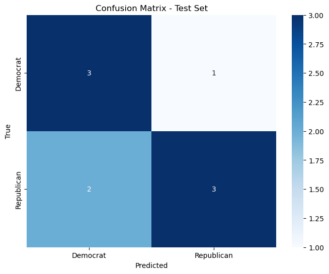

```
Cross-Validation Accuracy: 0.6583333333333333
```

```python
# Define features and target
X = z_score_df.drop(columns=["Year", "Party_Democratic", "Party_Republican", "Residency", "Birthplace", "House Majority_Democrat", "Senate Majority_Democrat"])  # Features
y = z_score_df["Party_Republican"]  # Target variable: 1=Republican, 0=Democrat

# Train-test split (20% test set)
X_train, X_test, y_train, y_test = train_test_split(X, y, test_size=0.2, random_state=42, stratify=y)

# Preprocessor: scale numerical features
numerical_features = X.columns
preprocessor = ColumnTransformer(
    transformers=[
        ("num", StandardScaler(), numerical_features)
    ]
)

# Define the pipeline with Random Forest
pipeline = Pipeline(steps=[
    ("preprocessor", preprocessor),
    ("classifier", RandomForestClassifier(random_state=42))
])

# Hyperparameter grid for GridSearchCV
param_grid = {
    "classifier__n_estimators": [100, 200, 300, 500],          # Number of trees
    "classifier__max_depth": [10, 20, 30, None],               # Tree depth
    "classifier__min_samples_split": [2, 5, 10],              # Minimum samples required to split a node
    "classifier__min_samples_leaf": [1, 2, 5],                # Minimum samples at a leaf node
    "classifier__max_features": ["sqrt", "log2", None]        # Number of features to consider at each split
}

# GridSearchCV to find the best parameters, this is a module of SKLearn
grid_search = GridSearchCV(pipeline, param_grid, cv=5, scoring="accuracy", n_jobs=-1)
grid_search.fit(X_train, y_train)

# Best model from grid search
best_model = grid_search.best_estimator_
best_params = grid_search.best_params_

# Evaluate the best model
y_pred = best_model.predict(X_test)
classification_rep = classification_report(y_test, y_pred)
conf_matrix = confusion_matrix(y_test, y_pred)

# Display results
print("Best Parameters:", best_params)
print("Classification Report:")
print(classification_rep)

# Confusion Matrix Visualization
plt.figure(figsize=(8, 6))
sns.heatmap(conf_matrix, annot=True, fmt="d", cmap="Blues", xticklabels=["Democrat", "Republican"], yticklabels=["Democrat", "Republican"])
plt.xlabel("Predicted")
plt.ylabel("True")
plt.title("Confusion Matrix - Test Set")
plt.show()

# Cross-Validation Accuracy
cv_scores = cross_val_score(best_model, X, y, cv=5, scoring="accuracy")
print("Cross-Validation Accuracy:", cv_scores.mean())
```

While this might look impressive, it could also indicate overfitting, especially for small datasets. Overfitting occurs when the model memorizes the training data instead of generalizing.

**Model Robustness:**

Since the prediction for 2024 is based solely on the 2023 data, we want to ensure the model is robust by testing it with cross-validation or introducing some noise to evaluate its generalization.

```python
# Perform cross-validation
cv_scores = cross_val_score(best_model, X_train, y_train, cv=5, scoring="accuracy")
print(f"Cross-Validation Accuracy: {cv_scores.mean() * 100:.2f}%")
```

```
Cross-Validation Accuracy: 78.10%
```

### Simulating Scenarios:

So what type of situations would lead to a Demeocrat or Republican getting elected? Since we were curious, we decided to simulate three economic scenarios for 2023 and try to find out.

Let's run this code to find which President from which political party will get elected.

```python
# Define 2023 row as the base
base_2023 = {
    "Yearly SP 500 Return (%)": 0.822913,
    "GDP": 2.315751,
    "Median CPI": 2.922437,
    "Median Home Price": 2.399236,
    "CPI Food": 2.291969,
    "Unemployment Rate": -1.551457,
    "Long Term Interest Rate": -0.548514,
    "Disposable Personal Income": 1.886226,
    "Consumer Confidence Index": -1.895853,
    "Senate Majority_Republican": 0,
    "House Majority_Republican": 0
}

# Define revised scenarios
scenarios = {
    "Optimistic": {
        **base_2023,
        "Yearly SP 500 Return (%)": 3.0,  # Strong stock market performance
        "GDP": 5.0,  # High economic growth
        "Median CPI": 1.5,  # Low inflation
        "Median Home Price": -1.0,  # Affordable housing
        "CPI Food": 1.0,  # Low food inflation
        "Unemployment Rate": -2.0,  # Extremely low unemployment
        "Long Term Interest Rate": -0.8,  # Favorable interest rates
        "Disposable Personal Income": 2.5,  # Higher personal income
        "Consumer Confidence Index": -1.0  # Improved confidence
    },
    "Pessimistic": {
        **base_2023,
        "Yearly SP 500 Return (%)": -3.0,  # Market decline
        "GDP": -2.0,  # Recession
        "Median CPI": 5.0,  # High inflation
        "Median Home Price": 5.0,  # Expensive housing
        "CPI Food": 6.0,  # Severe food inflation
        "Unemployment Rate": 4.0,  # High unemployment
        "Long Term Interest Rate": 1.5,  # Higher interest rates
        "Disposable Personal Income": 0.5,  # Lower personal income
        "Consumer Confidence Index": -3.0  # Poor confidence
    },
    "Neutral": {
        **base_2023  # All variables remain unchanged
    }
}

# Convert scenarios to DataFrame
scenarios_df = pd.DataFrame.from_dict(scenarios, orient="index")

# Display the updated scenarios
scenarios_df
```

|  | Yearly SP 500 Return (%) | GDP | Median CPI | Median Home Price | CPI Food | Unemployment Rate | Long Term Interest Rate | Disposable Personal Income | Consumer Confidence Index | Senate Majority_Republican | House Majority_Republican |
| --- | --- | --- | --- | --- | --- | --- | --- | --- | --- | --- | --- |
| Optimistic | 3.000000 | 5.000000 | 1.500000 | -1.000000 | 1.000000 | -2.000000 | -0.800000 | 2.500000 | -1.000000 | 0 | 0 |
| Pessimistic | -3.000000 | -2.000000 | 5.000000 | 5.000000 | 6.000000 | 4.000000 | 1.500000 | 0.500000 | -3.000000 | 0 | 0 |
| Neutral | 0.822913 | 2.315751 | 2.922437 | 2.399236 | 2.291969 | -1.551457 | -0.548514 | 1.886226 | -1.895853 | 0 | 0 |

Now that we have simulated these, we can use our model and this economic data to see which party will gain power.

```python
# Convert scenarios to DataFrame
scenarios_df = pd.DataFrame.from_dict(scenarios, orient="index")

# Ensure the columns match the model's input features
scenarios_df = scenarios_df[X.columns]  # Select only the columns used in training

# Preprocess scenarios and predict
scenario_predictions = best_model.predict(scenarios_df)
scenario_probabilities = best_model.predict_proba(scenarios_df)

# Attach predictions and probabilities to the DataFrame
scenarios_df["Prediction"] = scenario_predictions
scenarios_df["Republican Probability"] = scenario_probabilities[:, 1]
scenarios_df["Democrat Probability"] = scenario_probabilities[:, 0]

# Display the results
scenarios_df[["Prediction", "Republican Probability", "Democrat Probability"]]
```

|  | Prediction | Republican Probability | Democrat Probability |
| --- | --- | --- | --- |
| Optimistic | 0 | 0.44 | 0.56 |
| Pessimistic | 1 | 0.59 | 0.41 |
| Neutral | 0 | 0.22 | 0.78 |

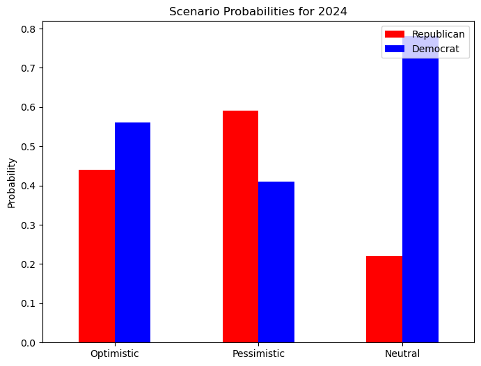

```python
# Plot probabilities with custom colors
scenarios_df[["Republican Probability", "Democrat Probability"]].plot.bar(
    color=["red", "blue"],  # Republican = Red, Democrat = Blue
    figsize=(8, 6)
)
plt.title("Scenario Probabilities for 2024")
plt.ylabel("Probability")
plt.xticks(range(len(scenarios_df)), scenarios_df.index, rotation=0)
plt.legend(["Republican", "Democrat"], loc="upper right")
plt.show()
```

As we can see on the graph above, Democrats seem to win the Optimistic and Neutral scenarios, which means Democrats should win a majority of the time when the economy is growing. When the economy is bad, Republican are more likely to win.

For analysis of the results, see below.

**Part II: The Prediction of Future Values:** Here, we could also use a some simple Regression and Interactive Terms Analysis to help forecast future values of economic indicators based on past election results. By analyzing trends in data like inflation or consumer confidence over time, we can understand how changes in political leadership might impact the economy going forward.

### Simple Linear Models###

To do this, we will be looking into the past, and creating a **regressive** model of the each economic factor based on whether the president is Republicain or Democrat. We will use this model to see how the next few years under the new administration will be. A few things to note though, because we are trying to predict economic values that are numbers, a we will be using a **regressive model** as opposed to a classification model. Second, we fully realize the impact of world events (such as COVID-19) on certain economic vectors, and that they may have some unexpected impact on our model.

Let's start by looking at inflation, and seeing if it increases more or less under an Republican or Democrat President. Please Note: we know that inflation is unfornately **always** increasing, hence the reason that Fred API registers it using inflation percentage from year to year, with the FED trying to keep it to [2% on average](https://www.federalreserve.gov/faqs/economy_14400.htm). Our question relates to whether if the rate of increase will be lower and higher pending on dominating political party. Read more about it [here](https://www.investopedia.com/terms/i/inflation.asp#:~:text=The%20inflation%20rate%20is%20calculated%20as%20the%20average,inflation%20means%20that%20prices%20are%20growing%20more%20slowly)

To begin, let's make our own DataFrame to play with.

```python
merged_df.columns
```

```
Index(['Year', 'President', 'Party', 'Birthplace', 'Residency',
       'Senate Majority', 'House Majority', 'Yearly SP 500 Return (%)', 'GDP',
       'GDP Change (%)', 'Inflation', 'Median CPI', 'Median Home Price',
       'Median Home Price Change (%)', 'CPI Food', 'CPI Food Change (%)',
       'Unemployment Rate', 'Long Term Interest Rate',
       'Disposable Personal Income', 'Disposable Personal Income Change (%)',
       'Consumer Confidence Index', 'CCI Z-Score'],
      dtype='object')
```

```python
presidential_party_inflation_df = merged_df[['Year','President','Party','Inflation']]
presidential_party_inflation_df.head()
```

|  | Year | President | Party | Inflation |
| --- | --- | --- | --- | --- |
| 0 | 1983 | Ronald Reagan | Republican | 3.21 |
| 1 | 1984 | Ronald Reagan | Republican | 4.30 |
| 2 | 1985 | Ronald Reagan | Republican | 3.55 |
| 3 | 1986 | Ronald Reagan | Republican | 1.90 |
| 4 | 1987 | Ronald Reagan | Republican | 3.66 |

Cool, now we use the .groupby function to group by what party was in charge. We will be putting the result into a list so that we can grab it later.

```python
inflation_by_party_df = presidential_party_inflation_df.groupby('Party')
#let's make a list to stick everything in.
inflation_party =[]
for name, group in inflation_by_party_df:
  #Adding the DataFrames to the list.
  inflation_party.append(group)
  #And for reference, let's display everything.
  display(group.head())
```

|  | Year | President | Party | Inflation |
| --- | --- | --- | --- | --- |
| 11 | 1994 | Bill Clinton | Democratic | 2.61 |
| 12 | 1995 | Bill Clinton | Democratic | 2.81 |
| 13 | 1996 | Bill Clinton | Democratic | 2.93 |
| 14 | 1997 | Bill Clinton | Democratic | 2.34 |
| 15 | 1998 | Bill Clinton | Democratic | 1.55 |

|  | Year | President | Party | Inflation |
| --- | --- | --- | --- | --- |
| 0 | 1983 | Ronald Reagan | Republican | 3.21 |
| 1 | 1984 | Ronald Reagan | Republican | 4.30 |
| 2 | 1985 | Ronald Reagan | Republican | 3.55 |
| 3 | 1986 | Ronald Reagan | Republican | 1.90 |
| 4 | 1987 | Ronald Reagan | Republican | 3.66 |

Now, let's try the regression, with the x-value being years, and the y-value being the inflation rate. Let's start with the Democrats.

```python
#Defining the x-value to be years, inflation_party[0] is the Democrats
x = inflation_party[0]['Year']
#Now, we get the y-values, which is inflation
y = inflation_party[0]['Inflation']

#Now, using a regression model
#the most important thing here is the slope and intercept
slope, intercept, r, p, std_err = sci.stats.linregress(x, y)

#Finally, let's build the equation, with future year (or years) being entered
def dem_inflation(x):
  return (slope*x)+intercept
```

Let's try this out.

```python
#Make a list of years now until the end of the next presidential term in 2029, adding a year because range takes one from the last of the list.
years = list(range(1983, 2030))
print(years)
```

```
[1983, 1984, 1985, 1986, 1987, 1988, 1989, 1990, 1991, 1992, 1993, 1994, 1995, 1996, 1997, 1998, 1999, 2000, 2001, 2002, 2003, 2004, 2005, 2006, 2007, 2008, 2009, 2010, 2011, 2012, 2013, 2014, 2015, 2016, 2017, 2018, 2019, 2020, 2021, 2022, 2023, 2024, 2025, 2026, 2027, 2028, 2029]
```

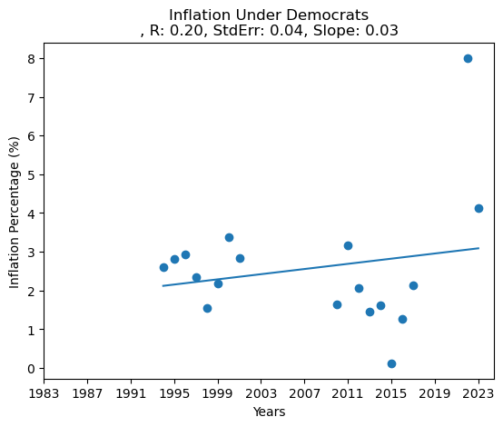

```python
#Deploy the model, inputing years to predict the future
demmodel = list(map(dem_inflation, x))
#and to plot it
plt.scatter(x, y)
plt.plot(x, demmodel)
plt.title(f"Inflation Under Democrats\n, R: {r:.2f}, StdErr: {std_err:.2f}, Slope: {slope:.2f}")
plt.xlabel('Years')
plt.ylabel('Inflation Percentage (%)')
plt.xticks(range(1983,2027,4))
plt.show()
```

As we can see here, the inflation rate seems to be going up under a Democratic President. More on this later.

Let's check on this using the standard error r!

```python
print('The colleration value here is {:.2f}'.format(r))
print('The standard error here is {:.2f}'.format(std_err))
```

```
The colleration value here is 0.20
The standard error here is 0.04
```

Let's do the same for the Republicans!

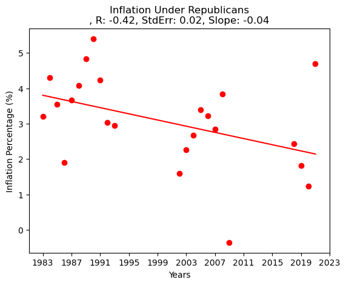

```python
#Defining the x-value to be years, inflation_party[0] is the Democrats
x = inflation_party[1]['Year']
#Now, we get the y-values, which is inflation
y = inflation_party[1]['Inflation']

#Now, using a regression model
#the most important thing here is the slope and intercept
slope, intercept, r, p, std_err = sci.stats.linregress(x, y)

#Finally, let's build the equation, with future year (or years) being entered
def repub_inflation(x):
  return (slope*x)+intercept

#Deploy the model, inputing years to predict the future
repubmodel = list(map(repub_inflation, x))
#and to plot it
plt.scatter(x, y,color='red')
plt.plot(x, repubmodel,color='red')
plt.title(f"Inflation Under Republicans\n, R: {r:.2f}, StdErr: {std_err:.2f}, Slope: {slope:.2f}")
plt.xlabel('Years')
plt.ylabel('Inflation Percentage (%)')
plt.xticks(range(1983,2027,4))
plt.show()
```

Um, what? Why is inflation going down? Well no, remember that this is the **rate of inflation**. What this visual is showing is that under Republican presidents, the inflation rate goes down.

Let's check the correlation value.

```python
print('The colleration value here is {:.2f}'.format(r))
print('The standard error here is {:.2f}'.format(std_err))
```

```
The colleration value here is -0.42
The standard error here is 0.02
```

More on this later...

Okay, now to try it for the rest of the values. We will group our DataFrame by party. To begin, I will be creating a few definition so we can run through all the functions and make graphs.

```python
from ast import expr_context
by_party = merged_df.groupby('Party')
#let's make a list to stick everything in.
econ_by_party =[]
for name, group in by_party:
  #Adding the DataFrames to the list.
  econ_by_party.append(group)
```

Let's also define the economic factors we are going through.

```python
factors_of_econ = ['Yearly SP 500 Return (%)', 'GDP', 'Inflation', 'Median CPI',
       'Median Home Price', 'CPI Food', 'Unemployment Rate',
       'Long Term Interest Rate', 'Disposable Personal Income',
       'Consumer Confidence Index']
```

Now to make the function, starting with Democrats.

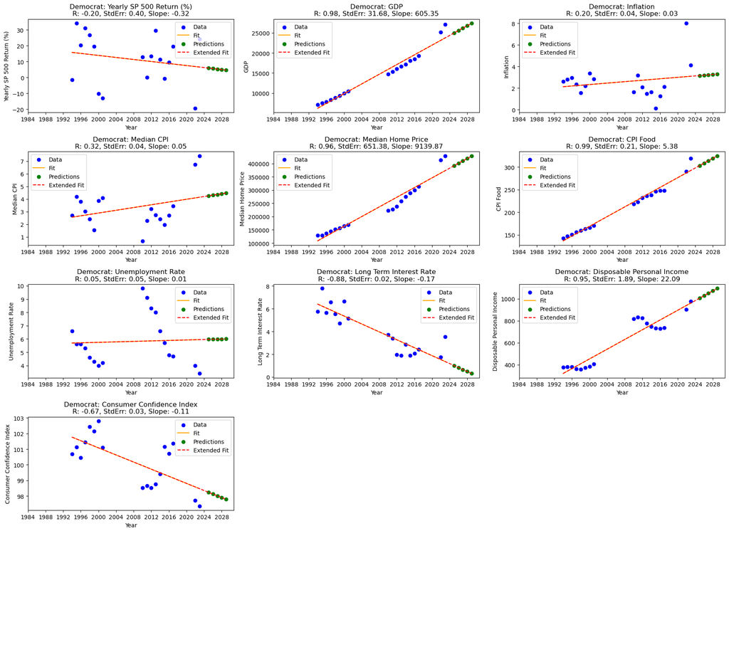

```python
# Define variables
x = econ_by_party[0]['Year']

# Years to predict
future_years = np.array([2025, 2026, 2027, 2028, 2029])

# Create a 4x3 grid (12 subplots)
fig, axes = plt.subplots(5, 3, figsize=(18, 16))
axes = axes.flatten()  # Flatten the 2D array for easier iteration

for i,factor in enumerate(factors_of_econ):
    y = econ_by_party[0][factor]
    slope, intercept, r, p, std_err = sci.stats.linregress(x, y)
    lgdemmodel = [slope * val + intercept for val in x]  # Calculate the regression line

    # Predict for future years
    future_predictions = [slope * year + intercept for year in future_years]

    # Scatter plot and regression line
    axes[i].scatter(x, y, label="Data", color="blue")
    axes[i].plot(x, lgdemmodel, label="Fit", color="orange")

    # Plot future predictions
    axes[i].scatter(future_years, future_predictions, color="green", label="Predictions")
    axes[i].plot(
        np.concatenate([x, future_years]),
        np.concatenate([lgdemmodel, future_predictions]),
        color="red", linestyle="dashed", label="Extended Fit"
    )

    # Title and annotations
    axes[i].set_title(f"Democrat: {factor}\nR: {r:.2f}, StdErr: {std_err:.2f}, Slope: {slope:.2f}")
    axes[i].set_xlabel("Year")
    axes[i].set_ylabel(factor)
    axes[i].legend()

    #Resetting the x-axis to reflect the presidential terms.
    axes[i].set_xticks(range(1984,2030,4))

# Hide unused subplots (axes[10], axes[11])
for j in range(len(factors_of_econ), len(axes)):
    axes[j].axis('off')

# Adjust layout for better visualization
plt.tight_layout()
plt.show()
```

Interestingly, correleation seems to be high in GDP, Median Home Price, CPI Food, Long Term Interest Rates, and Disposiable Personal Income.

Let's try the Republicans right now.

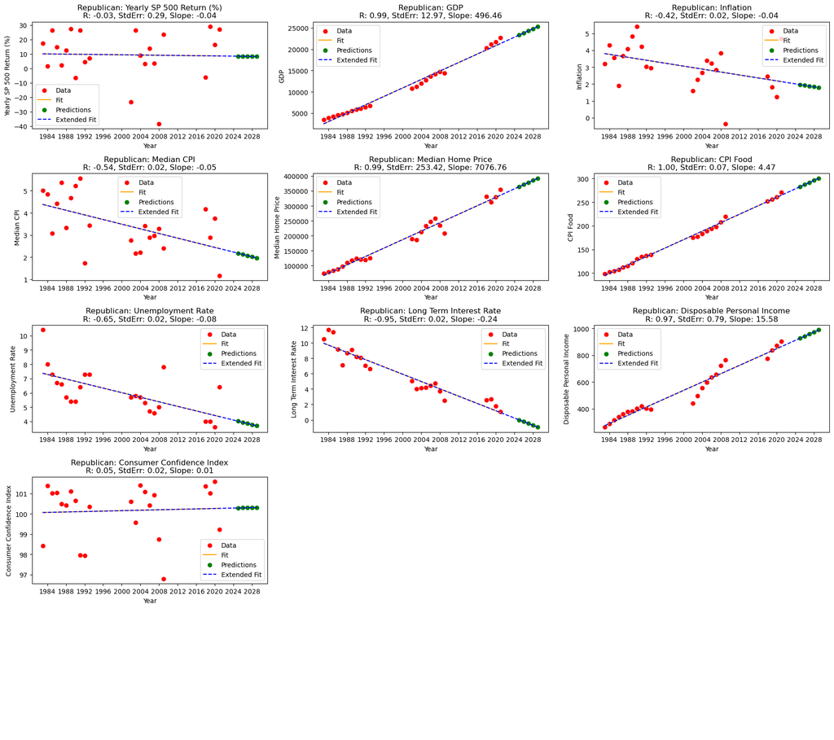

```python
# Define variables
x = econ_by_party[1]['Year']


# Years to predict
future_years = np.array([2025, 2026, 2027, 2028, 2029])

# Create a 4x3 grid (12 subplots)
fig, axes = plt.subplots(5, 3, figsize=(18, 16))
axes = axes.flatten()  # Flatten the 2D array for easier iteration

for i, factor in enumerate(factors_of_econ):
    y = econ_by_party[1][factor]
    slope, intercept, r, p, std_err = sci.stats.linregress(x, y)
    lgrepubmodel = [slope * val + intercept for val in x]  # Calculate the regression line

    # Predict for future years
    future_predictions = [slope * year + intercept for year in future_years]

    # Scatter plot and regression line
    axes[i].scatter(x, y, label="Data", color="red")
    axes[i].plot(x, lgrepubmodel, label="Fit", color="orange")

    # Plot future predictions
    axes[i].scatter(future_years, future_predictions, color="green", label="Predictions")
    axes[i].plot(
        np.concatenate([x, future_years]),
        np.concatenate([lgrepubmodel, future_predictions]),
        color="blue", linestyle="dashed", label="Extended Fit"
    )

    # Title and annotations
    axes[i].set_title(f"Republican: {factor}\nR: {r:.2f}, StdErr: {std_err:.2f}, Slope: {slope:.2f}")
    axes[i].set_xlabel("Year")
    axes[i].set_ylabel(factor)
    axes[i].legend()

    axes[i].set_xticks(range(1984,2030,4))

# Hide unused subplots (axes[10], axes[11])
for j in range(len(factors_of_econ), len(axes)):
    axes[j].axis('off')

# Adjust layout for better visualization
plt.tight_layout()
plt.show()
```

Here, the factors with high correlation are GDP, Median Home Price, CPI Food, Long Term Interest Rate, and Disposable personal income. We will analyze these and their future values later, but we should note that both plots have the same same features with high correlation.

However, is this the entire story? Let's look at both the Republicans and Democrats on the same graph.

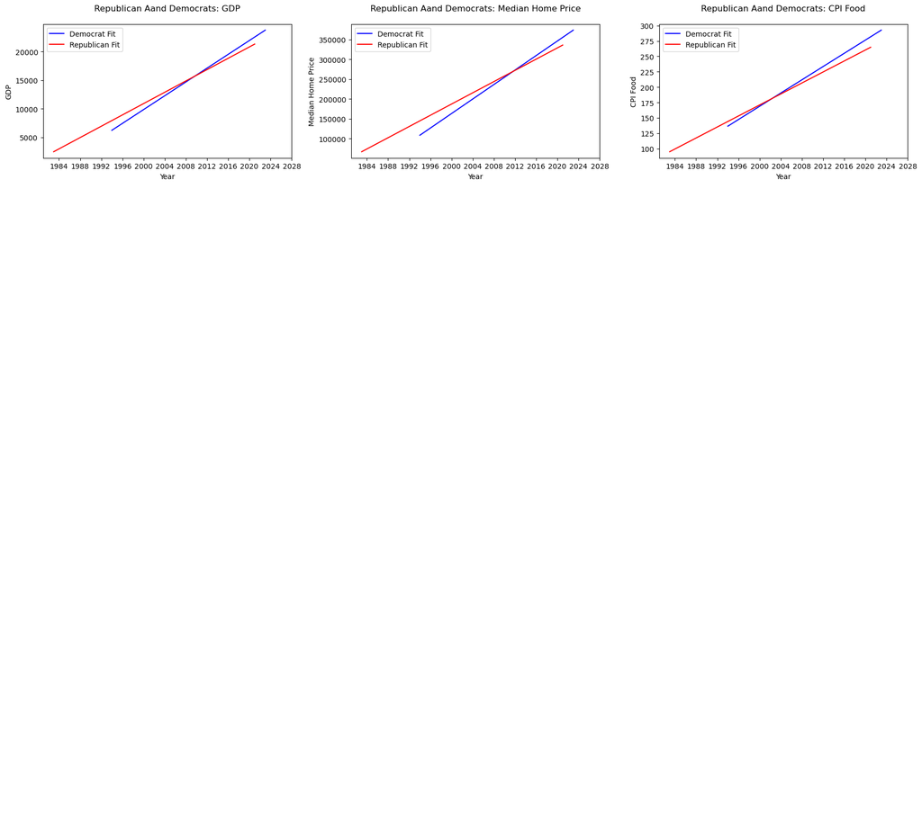

```python
# Define variables
x1 = econ_by_party[0]['Year']
x2 = econ_by_party[1]['Year']

#Just the three we need
major_factors_of_econ = ['GDP','Median Home Price', 'CPI Food']


# Years to predict
future_years = np.array([2025, 2026, 2027, 2028, 2029])

# Create a 1x3 grid (3 subplots)
fig, axes = plt.subplots(5, 3, figsize=(18, 16))
axes = axes.flatten()  # Flatten the 2D array for easier iteration

for i, factor in enumerate(major_factors_of_econ):
    y1 = econ_by_party[0][factor]
    y2 = econ_by_party[1][factor]
    slope1, intercept1, r1, p1, std_err1 = sci.stats.linregress(x1, y1)
    slope2, intercept2, r2, p2, std_err2 = sci.stats.linregress(x2, y2)
    dmodel = [slope1 * val + intercept1 for val in x1]
    rmodel = [slope2 * val + intercept2 for val in x2]

    # Plot and Regression lines
    axes[i].plot(x1, dmodel, label="Democrat Fit", color="blue")
    axes[i].plot(x2, rmodel, label="Republican Fit", color="red")

    # Title and annotations
    axes[i].set_title(f"Republican Aand Democrats: {factor}\n")
    axes[i].set_xlabel("Year")
    axes[i].set_ylabel(factor)
    axes[i].legend()

    axes[i].set_xticks(range(1984,2030,4))

# Hide unused subplots (axes[10], axes[11])
for j in range(len(major_factors_of_econ), len(axes)):
    axes[j].axis('off')

# Adjust layout for better visualization
plt.tight_layout()
plt.show()
```

As we can see, there is not much seperating between the two. Is this entire story? As we saw above, maybe we have to take into account the change by year?

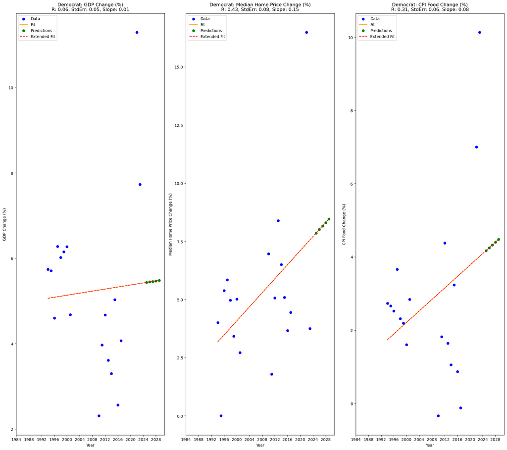

```python
# Define variables
x = econ_by_party[0]['Year']

factors_of_econ2 = [ 'GDP Change (%)','Median Home Price Change (%)','CPI Food Change (%)']

# Years to predict
future_years = np.array([2025, 2026, 2027, 2028, 2029])

# Create a 1x3 grid 3 subplots)
fig, axes = plt.subplots(1, 3, figsize=(18, 16))
axes = axes.flatten()  # Flatten the 2D array for easier iteration

for i,factor in enumerate(factors_of_econ2):
    y = econ_by_party[0][factor]
    slope, intercept, r, p, std_err = sci.stats.linregress(x, y)
    lgdemmodel = [slope * val + intercept for val in x]  # Calculate the regression line

    # Predict for future years
    future_predictions = [slope * year + intercept for year in future_years]

    # Scatter plot and regression line
    axes[i].scatter(x, y, label="Data", color="blue")
    axes[i].plot(x, lgdemmodel, label="Fit", color="orange")

    # Plot future predictions
    axes[i].scatter(future_years, future_predictions, color="green", label="Predictions")
    axes[i].plot(
        np.concatenate([x, future_years]),
        np.concatenate([lgdemmodel, future_predictions]),
        color="red", linestyle="dashed", label="Extended Fit"
    )

    # Title and annotations
    axes[i].set_title(f"Democrat: {factor}\nR: {r:.2f}, StdErr: {std_err:.2f}, Slope: {slope:.2f}")
    axes[i].set_xlabel("Year")
    axes[i].set_ylabel(factor)
    axes[i].legend()

    #Resetting the x-axis to reflect the presidential terms.
    axes[i].set_xticks(range(1984,2030,4))

# Hide unused subplots (axes[10], axes[11])
for j in range(len(factors_of_econ), len(axes)):
    axes[j].axis('off')

# Adjust layout for better visualization
plt.tight_layout()
plt.show()
```

Wow. These graphs are *very* different. Maybe we are not measuring what we think we are. Perhaps instead of looking at these factors, we are actually looking at inflation.

### 6. Hypothesis Testing

- **Define Hypotheses:**

  The **null hypothesis** assumes there is *no significant relationship* between the predictor variables and the election outcome

  H₀: Economic and political factors (e.g., GDP, CPI Food, Median Home Price) do not significantly predict the 2024 presidential election outcome.

  The alternative hypothesis assumes that economic and political factors do significantly predict the 2024 presidential election outcome.

  H₁: At least one of the economic or political factors (e.g., GDP, CPI Food, Median Home Price) does significantly predict the 2024 presidential election outcome.
- **Statistical Tests:**

  H₀: The coefficients (or feature importances) of the predictor variables are equal to zero.

To do this, we will begin by getting the features of the random forest model that we made earlier and the graph them by their calculated importance using the [.feature_importances_](https://scikit-learn.org/stable/auto_examples/ensemble/plot_forest_importances.html) function

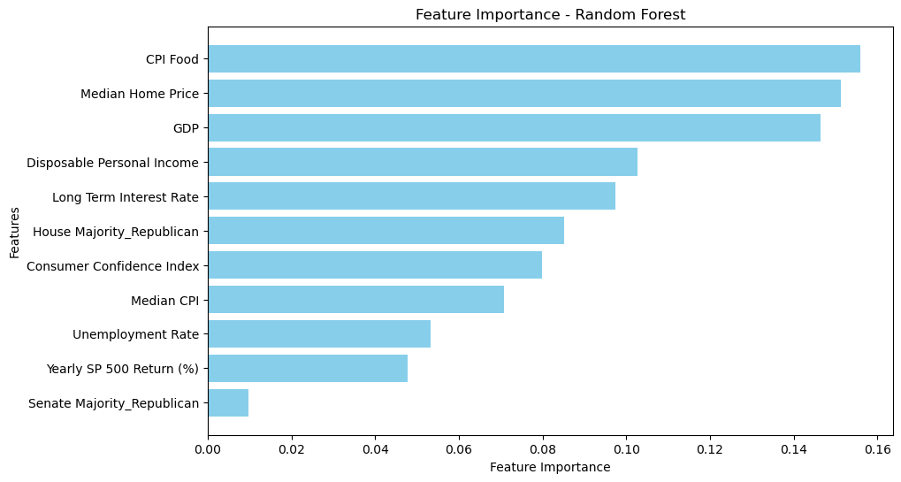

|  | Feature | Importance |
| --- | --- | --- |
| 4 | CPI Food | 0.155892 |
| 3 | Median Home Price | 0.151224 |
| 1 | GDP | 0.146347 |
| 7 | Disposable Personal Income | 0.102614 |
| 6 | Long Term Interest Rate | 0.097475 |
| 10 | House Majority_Republican | 0.085200 |
| 8 | Consumer Confidence Index | 0.079903 |
| 2 | Median CPI | 0.070830 |
| 5 | Unemployment Rate | 0.053144 |
| 0 | Yearly SP 500 Return (%) | 0.047721 |
| 9 | Senate Majority_Republican | 0.009651 |

```python
# Extract feature importances from the Random Forest
importances = best_model.named_steps["classifier"].feature_importances_
feature_names = X.columns

# Create a DataFrame for better visualization
importance_df = pd.DataFrame({
    "Feature": feature_names,
    "Importance": importances
}).sort_values(by="Importance", ascending=False)

# Plot feature importance
plt.figure(figsize=(10, 6))
plt.barh(importance_df["Feature"], importance_df["Importance"], color="skyblue")
plt.xlabel("Feature Importance")
plt.ylabel("Features")
plt.title("Feature Importance - Random Forest")
plt.gca().invert_yaxis()  # Highest importance at the top
plt.show()

# Print the feature importance values
importance_df
```

### Checking P-Values###

We are using **permutation testing** to check if the relationship between the economic indicators (features) and the political outcomes is meaningful or just random. Random Forest models don’t give p-values like traditional statistics, so we shuffle the labels (e.g., Republican/Democrat) many times and measure how well the model predicts with the shuffled data. Then, we compare this to the accuracy of the model with the real data. If the model with the real data performs much better than the shuffled ones, it shows that the features are actually useful for making predictions, and we can reject the idea that the results happened by chance.

```python
from sklearn.metrics import accuracy_score

# Step 1: Calculate the accuracy of the original model
original_accuracy = accuracy_score(y_test, best_model.predict(X_test))

# Step 2: Perform permutation testing
n_permutations = 1000
permuted_accuracies = []

for i in range(n_permutations):
    # Shuffle the target variable
    y_permuted = np.random.permutation(y_train)

    # Re-train the model on the permuted data
    best_model.fit(X_train, y_permuted)

    # Calculate accuracy on the test set
    permuted_accuracy = accuracy_score(y_test, best_model.predict(X_test))
    permuted_accuracies.append(permuted_accuracy)

# Step 3: Calculate p-value
permuted_accuracies = np.array(permuted_accuracies)
p_value = np.mean(permuted_accuracies >= original_accuracy)

print("Original Accuracy:", original_accuracy)
print("p-value:", p_value)
```

```
Original Accuracy: 0.6666666666666666
p-value: 0.235
```

**Original Accuracy:** 66.67%

**p-value:** 0.23

**Interpretation:**

Since the p-value (0.23) is much greater than 0.05, **we cannot reject the null hypothesis.**

This suggests that the model's accuracy might not be significantly better than what could be achieved by chance. In other words, the features may not have a strong predictive relationship with the political outcomes.

### Analysis of Party Economy Growth###

We really found that we were not graphing economics, just the inflation really. Technically, this proved nothing.

**Key Observations**

**Hypothesis Testing**

1. **Null Hypothesis (H₀):**

Economic and political factors do not significantly predict the 2024 presidential election outcome.

### 7. Results Interpretation

Our model is only accurate in predicting the party of the next president about two-thirds of the time.

- **Limitations:** Obviously, this is just one perspective on the election of a president. It does not take into account the social position, international events, or incumbancy. Hence the reason that our model is not a 100% accurate or percise all the time. There is simply so much more that goes through the mind of a voter in a voting booth than just thier current economic situation.

Secondly, we were limited in the scope of our data by time, as the earliest year that the Federal Reserve has data for some parts of our Data Frame was 1983 under Ronald Reagan.

- **Recommondations of Future Research:** Beyond including the limitations into our model, we may also wich to go and see how each individual state's economics may factor into the presdiency, though this would be an absurdly large DataFrame to parse through, and may result in overfitting due to its specificity.